# Project_ULC-RFMAnalysisECommerce

[figure not shown]

**DataScience Portfolio**  
**Enrique Otero Espinosa**  
**https://github.com/eoroot1974/DataSciencePortfolio**

**Machine Learning Unsupervised Algorithms**  
Clustering with Traditional ML KMeans Algorithm

Project Name:  
Project_ULC-RFMAnalysisECommerce  
Project Location:  
[Clustering with Traditional ML KMeans Algorithm: RFM Analysis on E-Commerce Customer Transactions Data](https://github.com/eoroot1974/DataSciencePortfolio/tree/main/MachineLearning/UnsupervisedLearning/ClusteringTraditionalMLKMeans/Project_ULC-RFMAnalysisECommerce)  
Date:  
June 8th, 2025

**TABLE OF CONTENTS**

Overview  
1. Libraries  
2. Data Loading, RFM Data Creation, and Raw & RFM Data Description  
2.1. Raw Data loading and Raw Data Description  
2.2. RFM Data Creation and RFM Data Description  
3. Exploratory Data Analysis (EDA)  
3.1. Dataset Structure and Data types  
3.1.1. Dataset Structure and Data types on Raw Dataset  
3.1.2. Dataset Structure and Data types on RFM Dataset  
3.2. Basic statistical information  
3.2.1. Statistical Basic Summary  
3.2.1.1. Statistical Basic Summary of Raw dataset  
3.2.1.2. Statistical Basic Summary of RFM dataset  
3.2.2. Outlier Analysis  
3.2.2.1. Outlier Analysis in Raw dataset  
3.2.2.1.1. Initial Outlier Detection  
3.2.2.1.2. Outlier Handling Methods (for Clustering)  
3.2.2.2. Outlier Analysis in RFM dataset  
3.2.2.2.1. Initial Outlier Detection  
3.2.2.2.2. Outlier Handling Methods (for Clustering)  
3.3. Features Graphical Analysis  
3.3.1. Features Graphical Analysis on RAW Dataset  
3.3.1.1. Key Revenue and Product Insights (RAW Dataset)  
3.3.1.2. Time-Based Analysis (RAW Dataset) (RAW Dataset)  
3.3.2. Features Graphical Analysis on RFM Dataset  
4. Clustering Analysis  
4.1. Final Dataset Creation for Clustering  
4.2. Number of Clusters initial Inference  
4.2.1. Clusters Inference with Elbow Method  
4.2.2. Clusters Inference with Silhouette Method  
4.3. Final Cluster Analysis using KMeans  
5. Final Results and Conclusions

```python
%%html
<style>
table {float:left}
</style>
```

# Overview

## Project Overview: RFM-Based Customer Segmentation with KMeans Clustering

This project applies unsupervised machine learning techniques—specifically **KMeans clustering**—to segment customers based on their **Recency**, **Frequency**, and **Monetary** (RFM) behavior in an e-commerce context. The goal is to discover meaningful customer groups to support targeted marketing strategies and operational decision-making.

### Objective

To identify distinct customer segments by analyzing their purchasing behavior and categorize them into clusters using KMeans. Each segment is interpreted from a business perspective to propose actionable strategies for retention, loyalty, or reactivation.

### Dataset and Preprocessing

The dataset contains RFM metrics per customer:

- **Recency**: Days since last purchase
- **Frequency**: Number of purchases
- **Monetary**: Total spending

To prepare the data:

- **Outliers were handled** using bi-weight transformation.
- **MinMax scaling** was applied to normalize the RFM values between 0 and 1.
- KMeans was run with two different configurations:
  - **K=3 clusters** (`rfmdata_bw_S_3C.csv`)
  - **K=4 clusters** (`rfmdata_bw_S_4C.csv`)
- Cluster assignments were merged back to the original unscaled data to compute real RFM averages per segment.

### Methodology

1. **KMeans Clustering**: Unsupervised grouping of customers based on similarity in RFM behavior.
2. **Evaluation of Cluster Centers**: Average values per cluster for Recency, Frequency, and Monetary were analyzed using denormalized data to improve interpretability.
3. **Cluster Profiling**:
   - Size of each cluster (number of customers)
   - RFM characteristics
   - Business interpretation of each group

### Use Cases and Business Value

- **Loyalty Programs**: Identify and reward high-frequency and high-monetary customers.
- **Churn Risk Management**: Detect recent inactivity to trigger win-back campaigns.
- **Resource Allocation**: Prioritize efforts on valuable or at-risk segments.

This segmentation enables **personalized marketing**, better **budget allocation**, and **improved customer lifetime value (CLV)** management.

### Tools Used

- Python (Pandas, Scikit-learn, Matplotlib)
- KMeans Clustering
- MinMaxScaler
- Custom profiling and denormalization logic

### Next Steps

- Evaluate more granular segmentations (e.g., K=5, K=6)
- Track customer transitions between clusters over time
- Integrate with campaign performance data for ROI analysis

# 1. Libraries

```python
# Data manipulation and numerical operations
import os # For OS data files and names manipulation
import numpy as np  # For numerical calculations and generating synthetic data
import pandas as pd  # For handling and manipulating data in tabular format

# Visualization libraries
import matplotlib.pyplot as plt  # For creating data visualizations
import seaborn as sns  # For enhanced data visualizations, like correlation plots

from scipy import stats
from scipy.stats.mstats import winsorize
from imblearn.over_sampling import SMOTE
from scipy import stats
import statsmodels.api as sm
from statsmodels.stats.outliers_influence import variance_inflation_factor
from statsmodels.tools.tools import add_constant
from sklearn.preprocessing import MinMaxScaler

from sklearn.cluster import KMeans
from sklearn.metrics import silhouette_score
#!pip install yellowbrick
from yellowbrick.cluster import SilhouetteVisualizer
```

# 2. Data Loading, RFM Data Creation, and Raw & RFM Data Description

This section covers the loading of the original Online Retail dataset, the transformation of transactional records into a customer-level RFM (Recency, Frequency, Monetary) dataset, and descriptive summaries of both the raw and RFM datasets.

The following subsections are included:

***Raw Data Loading and Raw Transactional Data Description***

The dataset is loaded from a local CSV file, ensuring correct encoding. Basic data types and structure are inspected and datset columns are described

***RFM Feature Engineering and RFM Data Description***

A new dataset is generated to support clustering analysis by summarizing customer behavior using the following metrics:

- **Recency**: Days since the customer's most recent transaction.
- **Frequency**: Number of unique transactions made by the customer.
- **Monetary**: Total amount spent by the customer across all transactions.

The dataset is cleaned before transformation by removing:

- Transactions with missing `CustomerID`
- Records with non-positive `Quantity` or `UnitPrice`

## 2.1. Raw Data loading and Raw Data Description

```python
# Load the dataset from the CSV file
data_path = '/home/dsninja/Documents/Shared/WorkArea/Anaconda/JupiterProjects/Project_ULC-RFMAnalysisECommerce/data'
date_file_name = 'OnlineRetail.csv'

full_file_path = os.path.join(data_path, date_file_name)
ordata = pd.read_csv(full_file_path, encoding='ISO-8859-1')

# Display the first few rows to inspect the data
ordata.head()
```

|  | InvoiceNo | StockCode | Description | Quantity | InvoiceDate | UnitPrice | CustomerID | Country |
| --- | --- | --- | --- | --- | --- | --- | --- | --- |
| 0 | 536365 | 85123A | WHITE HANGING HEART T-LIGHT HOLDER | 6 | 12/1/2010 8:26 | 2.55 | 17850.0 | United Kingdom |
| 1 | 536365 | 71053 | WHITE METAL LANTERN | 6 | 12/1/2010 8:26 | 3.39 | 17850.0 | United Kingdom |
| 2 | 536365 | 84406B | CREAM CUPID HEARTS COAT HANGER | 8 | 12/1/2010 8:26 | 2.75 | 17850.0 | United Kingdom |
| 3 | 536365 | 84029G | KNITTED UNION FLAG HOT WATER BOTTLE | 6 | 12/1/2010 8:26 | 3.39 | 17850.0 | United Kingdom |
| 4 | 536365 | 84029E | RED WOOLLY HOTTIE WHITE HEART. | 6 | 12/1/2010 8:26 | 3.39 | 17850.0 | United Kingdom |

**Explanation of the Raw Dataset columns**

| Variable Name | Variable Description | Variable Type | Unit | CL type |
| --- | --- | --- | --- | --- |
| **InvoiceNo** | Unique identifier for each invoice transaction. | Categorical (string) | None | Independent |
| **StockCode** | Product/item identifier (SKU). | Categorical (string) | None | Independent |
| **Description** | Description of the product/item. | Categorical (string) | None | Independent |
| **Quantity** | Number of items purchased in the transaction. | Numeric (integer) | Units | Independent |
| **InvoiceDate** | Date and time when the transaction was made. | Datetime | Timestamp | Independent |
| **UnitPrice** | Price per unit of the product. | Numeric (float) | GBP (£) | Independent |
| **CustomerID** | Unique identifier for the customer. | Categorical (string) | None | Independent |
| **Country** | Country where the customer resides or the order was placed. | Categorical (string) | None | Independent |

## 2.2. RFM Data creation and RFM Data Description

```python
# 1. Clean the dataset
rfm_source_data = ordata.copy()
rfm_source_data = rfm_source_data.dropna(subset=["CustomerID"])
rfm_source_data = rfm_source_data[(rfm_source_data["Quantity"] > 0) & (rfm_source_data["UnitPrice"] > 0)]
rfm_source_data["InvoiceDate"] = pd.to_datetime(rfm_source_data["InvoiceDate"])

# 2. Define the reference date (day after last invoice)
reference_date = rfm_source_data["InvoiceDate"].max() + pd.Timedelta(days=1)

# 3. Compute RFM features
rfmdata = rfm_source_data.groupby("CustomerID").agg({
    "InvoiceDate": lambda x: (reference_date - x.max()).days,  # Recency
    "InvoiceNo": "nunique",                                     # Frequency
    "Quantity": lambda x: np.sum(x * rfm_source_data.loc[x.index, "UnitPrice"])  # Monetary
}).reset_index()

# 4. Rename columns
rfmdata.columns = ["CustomerID", "Recency", "Frequency", "Monetary"]
rfmdata.head(5)
```

|  | CustomerID | Recency | Frequency | Monetary |
| --- | --- | --- | --- | --- |
| 0 | 12346.0 | 326 | 1 | 77183.60 |
| 1 | 12347.0 | 2 | 7 | 4310.00 |
| 2 | 12348.0 | 75 | 4 | 1797.24 |
| 3 | 12349.0 | 19 | 1 | 1757.55 |
| 4 | 12350.0 | 310 | 1 | 334.40 |

**Explanation of the RFM Dataset columns**

| Variable Name | Variable Description | Variable Type | Unit | CL type |
| --- | --- | --- | --- | --- |
| **CustomerID** | Unique identifier for each customer. | Categorical (float) | None | Independent |
| **Recency** | Number of days since the customer’s last purchase (lower means more recent). | Numeric (integer) | Days | Independent |
| **Frequency** | Total number of unique transactions (invoices) by the customer. | Numeric (integer) | Count | Independent |
| **Monetary** | Total amount spent by the customer across all purchases. | Numeric (float) | GBP | Independent |

# 3. Exploratory Data analysis (EDA)

## 3.1. Dataset Structure and Data types

### 3.1.1. Dataset Structure and Data types on Raw Dataset

```python
# Display the shape (dimensions) of the dataset
print("Dataset shape:", ordata.shape)

# Display the data types of each column
print("\nData types:\n", ordata.dtypes)
```

```
Dataset shape: (541909, 8)

Data types:
 InvoiceNo       object
StockCode       object
Description     object
Quantity         int64
InvoiceDate     object
UnitPrice      float64
CustomerID     float64
Country         object
dtype: object
```

The following information can be extracted:  
**Dataset Shape: (541909, 8)**  
The dataset has 541,909 rows and 8 columns. Each row represents a single transaction from an online retail store. The columns contain details such as the invoice number, product code and description, quantity purchased, date and time of the transaction, unit price, customer identifier, and the country where the purchase occurred. This dataset is primarily used for customer behavior analysis and market segmentation using unsupervised learning techniques like clustering.

**Data Types:**  
InvoiceNo: **object**. A unique alphanumeric identifier for each invoice, stored as a string.  
StockCode: **object**. A unique identifier for each product or item (SKU), stored as a string.  
Description: **object**. A textual description of the product, stored as a string.  
Quantity: **int64**. The number of units purchased in the transaction, stored as integers.  
InvoiceDate: **object**. The timestamp when the invoice was generated, currently stored as a string and should be converted to datetime for analysis.  
UnitPrice: **float64**. The price per unit of the product, stored as a floating-point number in GBP (£).  
CustomerID: **float64**. A unique identifier for each customer, stored as a float due to missing values but represents an ID.  
Country: **object**. The country from which the order was placed or where the customer is located, stored as a string.

⚠️ Note: This dataset does not contain a dependent (target) variable, as it’s typically used for unsupervised learning (e.g., clustering, association rules).

**Null or NaN values in Raw Dataset**  
You can check for null or NaN values in your dataset using the isnull() and sum() functions from pandas. Here’s the code to find if there are any null or NaN values in your dataset:

```python
# Check for null or NaN values in the dataset
null_values = ordata.isnull().sum()

# Display the result
print("Null or NaN values in the Raw dataset:\n", null_values)
```

```
Null or NaN values in the Raw dataset:
 InvoiceNo           0
StockCode           0
Description      1454
Quantity            0
InvoiceDate         0
UnitPrice           0
CustomerID     135080
Country             0
dtype: int64
```

The dataset was checked for missing (`NaN`) values using the `.isnull().sum()` function. The result reveals that not all columns are fully populated:

[output not shown]

**Conclusion:**

- The large number of missing values in `CustomerID` suggests a need for data cleaning before applying clustering.
- Rows with missing `CustomerID` should be removed in the data preparation step since they cannot be used to identify individual customers for segmentation.

We will deal this NaNs later on this notebook

### 3.1.2. Dataset Structure and Data types on RFM Dataset

```python
# Display the shape (dimensions) of the dataset
print("Dataset shape:", rfmdata.shape)

# Display the data types of each column
print("\nData types:\n", rfmdata.dtypes)
```

```
Dataset shape: (4338, 4)

Data types:
 CustomerID    float64
Recency         int64
Frequency       int64
Monetary      float64
dtype: object
```

The following information can be extracted:  
**Dataset Shape: (4338, 4)**  
The dataset has 4,338 rows and 4 columns. Each row represents a unique customer, aggregated from the original transactional dataset. The columns summarize customer purchasing behavior using Recency, Frequency, and Monetary value. This dataset is designed for behavior-based segmentation using unsupervised learning techniques such as clustering.

**Data Types:**  
CustomerID: **float64**. A unique identifier for each customer. Although numeric, it serves as a categorical ID and does not carry quantitative meaning.  
Recency: **int64**. The number of days since the customer's last transaction, measured relative to the most recent date in the dataset. Lower values indicate more recent activity.  
Frequency: **int64**. The total number of unique purchase transactions (invoices) made by the customer. Higher values indicate more frequent purchasing behavior.  
Monetary: **float64**. The total monetary value of all purchases made by the customer, calculated as the sum of `Quantity × UnitPrice`.

⚠️ Note: This dataset does not contain a dependent (target) variable. It is designed for **unsupervised learning** tasks such as clustering to uncover latent customer segments based on purchasing patterns.

**Null or NaN values in RFM Dataset**

```python
# Check for null or NaN values in the dataset
null_values = rfmdata.isnull().sum()

# Display the result
print("Null or NaN values in the RFM dataset:\n", null_values)
```

```
Null or NaN values in the RFM dataset:
 CustomerID    0
Recency       0
Frequency     0
Monetary      0
dtype: int64
```

A check for missing (`NaN`) values in the RFM dataset confirms that there are **no null values** across any of the four columns: `CustomerID`, `Recency`, `Frequency`, and `Monetary`. This ensures the dataset is complete and ready for further analysis, such as scaling and clustering, without requiring imputation or record removal.

## 3.2. Basic Statistical Information

This section provides a detailed statistical overview of both the raw transactional dataset and the aggregated RFM dataset. The goal is to understand the distribution, scale, and behavior of key variables before moving on to normalization and clustering.

Understanding the underlying statistics is essential in clustering tasks because most clustering algorithms — particularly distance-based methods like K-Means — are sensitive to the scale and variability of the input features. Anomalous values or skewed distributions can distort distances between points and lead to suboptimal or misleading clusters.

The analysis begins with **descriptive statistics** (mean, standard deviation, percentiles, etc.) to summarize key characteristics of the data, followed by a structured **outlier analysis** to detect and mitigate the effect of extreme values that could bias clustering outcomes.

The statistical examination is performed at two levels:

- **Raw Dataset Level**: Analyzing individual transaction records such as `Quantity` and `UnitPrice`.
- **RFM Dataset Level**: Analyzing customer-level aggregated features — `Recency`, `Frequency`, and `Monetary` — derived from the raw dataset.

By exploring both datasets, we ensure a comprehensive understanding of the data before transformation and modeling. The insights gathered here will directly inform decisions in the next phases, including feature scaling, cluster selection, and model evaluation.

### 3.2.1. Statistical Basic Summary

#### 3.2.1.1. Statistical Basic Summary of Raw dataset

```python
# Get basic statistical information about the dataset
statistical_summary = ordata.describe()

# Display the result
statistical_summary.style.set_caption("Statistical Summary of Raw dataset")
```

Statistical Summary of Raw dataset

|  | Quantity | UnitPrice | CustomerID |
| --- | --- | --- | --- |
| count | 541909.000000 | 541909.000000 | 406829.000000 |
| mean | 9.552250 | 4.611114 | 15287.690570 |
| std | 218.081158 | 96.759853 | 1713.600303 |
| min | -80995.000000 | -11062.060000 | 12346.000000 |
| 25% | 1.000000 | 1.250000 | 13953.000000 |
| 50% | 3.000000 | 2.080000 | 15152.000000 |
| 75% | 10.000000 | 4.130000 | 16791.000000 |
| max | 80995.000000 | 38970.000000 | 18287.000000 |

The `describe()` method was applied to the numerical columns of the dataset: `Quantity`, `UnitPrice`, and `CustomerID`. Below is a summary and interpretation of the main statistics:

**Quantity**

- **Count:** 541,909 transactions include quantity information.
- **Mean:** The average number of units per transaction is approximately 9.55.
- **Std:** High standard deviation (~218.08) indicates wide variability in quantities.
- **Min:** Extremely negative value (-80,995) suggests the presence of returns or incorrect entries.
- **Max:** A maximum of 80,995 units in a single transaction is abnormally high and likely an outlier.
- **Insight:** Both minimum and maximum values suggest the need for outlier filtering before analysis.

**UnitPrice**

- **Mean:** Average unit price is £4.61, which is reasonable for small retail items.
- **Min:** -£11,062.06 indicates erroneous or refund-related values.
- **Max:** £38,970.00 is extremely high, possibly an error or rare luxury item.
- **Insight:** Presence of extreme and negative values warrants cleaning or capping strategies.

**CustomerID**

- **Count:** Only 406,829 rows (out of 541,909) have customer IDs, meaning ~25% are missing.
- **Range:** IDs range from 12,346 to 18,287 and appear to be anonymized numeric identifiers.
- **Insight:** Rows without CustomerID should be excluded from clustering, as they can't be linked to individuals.

Conclusion:

- The data contains clear **outliers** and **invalid values** (e.g., negative quantities and prices).
- **Cleaning and transformation** steps are essential before applying any clustering algorithm.

**EXPLANATION OF STANDARD DEVIATION** How to Interpret if Standard Deviation is High or Low

When describing variability in a dataset, the **standard deviation (σ)** is evaluated in relation to the **mean (μ)**.  
A general rule of thumb is to compare the ratio **σ / μ** (called the *coefficient of variation, CV*).

- **Low variability**:  
  If `σ / μ < 0.2` (less than 20%), the spread is considered small compared to the mean.  
  → Data points are clustered close to the average.
- **Moderate variability**:  
  If `0.2 ≤ σ / μ ≤ 0.5`, the spread is moderate.  
  → Data points are fairly dispersed, but the mean still represents the dataset reasonably well.
- **High variability**:  
  If `σ / μ > 0.5` (greater than 50%), the spread is large relative to the mean.  
  → Data is widely spread, and extreme values (outliers) are more likely.

**Example (Raw Dataset – Quantity)**

- Mean (μ) ≈ 9.55
- Std (σ) ≈ 218.08
- Ratio σ/μ = 218.08 / 9.55 ≈ **22.8**

Since this ratio is **>> 0.5**, the standard deviation is considered **extremely high**, confirming that outliers (very large or negative quantities) are distorting the distribution. **Conclusion** Calling a standard deviation “high” is not about the absolute value, but about its size **relative to the mean**. The coefficient of variation provides a consistent, general rule for interpretation across different variables and datasets.

#### 3.2.1.2. Statistical Basic Summary of RFM dataset

```python
# Get basic statistical information about the dataset
statistical_summary = rfmdata.describe()

# Display the result
statistical_summary.style.set_caption("Statistical Summary of RFM dataset")
```

Statistical Summary of RFM dataset

|  | CustomerID | Recency | Frequency | Monetary |
| --- | --- | --- | --- | --- |
| count | 4338.000000 | 4338.000000 | 4338.000000 | 4338.000000 |
| mean | 15300.408022 | 92.536422 | 4.272015 | 2054.266460 |
| std | 1721.808492 | 100.014169 | 7.697998 | 8989.230441 |
| min | 12346.000000 | 1.000000 | 1.000000 | 3.750000 |
| 25% | 13813.250000 | 18.000000 | 1.000000 | 307.415000 |
| 50% | 15299.500000 | 51.000000 | 2.000000 | 674.485000 |
| 75% | 16778.750000 | 142.000000 | 5.000000 | 1661.740000 |
| max | 18287.000000 | 374.000000 | 209.000000 | 280206.020000 |

The `describe()` method was applied to the numerical columns of the **RFM dataset**: `Recency`, `Frequency`, and `Monetary`. Below is a summary and interpretation of the main statistics:

**Recency**

- **Count:** 4,338 customers have valid Recency values.
- **Mean:** The average recency is approximately 92.54 days, meaning most customers last purchased around three months ago.
- **Std:** The standard deviation (~100.01) shows a wide spread in recency, indicating very recent as well as long-inactive customers.
- **Min:** 1 day — some customers made a purchase right before the reference date.
- **Max:** 374 days — indicates customers who haven’t purchased in over a year.
- **Insight:** The broad recency range will influence clustering strongly; normalization is essential to balance its impact.

**Frequency**

- **Mean:** On average, customers made about 4.27 transactions.
- **Std:** A relatively high standard deviation (~7.70) reflects a few highly frequent buyers.
- **Min / Max:** Frequency ranges from 1 to 209 — this long tail could create skewness in clustering.
- **Insight:** Many customers only made a single purchase, while some are repeat buyers. Log transformation may improve distribution symmetry.

Conclusion:

- The RFM dataset exhibits **heavy right-skewness** in both `Frequency` and `Monetary` due to the presence of high-frequency and high-value customers.
- **Recency** shows a wide spread, indicating the dataset captures customers across various lifecycle stages (e.g., recent, dormant).
- **Normalization** or **log transformation** will be critical before clustering to avoid dominance of extreme values.
- No missing values are present, and the dataset is clean and ready for further graphical analysis and preprocessing.

### 3.2.2. Outlier Analysis

Detecting outliers before applying clustering algorithms is a critical step in ensuring high-quality, interpretable customer segmentation—**not only in the raw transaction-level data but also in the engineered RFM dataset**.

Clustering algorithms—especially centroid-based ones like **K-Means**—are highly sensitive to extreme values. Outliers can:

- **Distort cluster centroids**, shifting them away from the true center of dense customer groups.
- **Lead to artificial clusters** that don’t represent real customer behavior.
- **Reduce the interpretability and actionability** of the final segments.
- **Inflate distance-based metrics**, such as inertia and silhouette score, causing misleading performance evaluation.

In the case of the **Raw dataset**, outliers in variables like `Quantity`, `UnitPrice`, and `CustomerID` may indicate returns, refunds, or data entry errors (e.g., negative or extreme values). These anomalies can propagate into RFM features if left unaddressed.

In the **RFM dataset**, even after aggregation, extreme values in `Recency`, `Frequency`, or `Monetary` may still exist—either due to high-spending customers or unusually inactive ones. These can skew distance metrics or dominate the clustering process unless properly handled.

***Outlier Detection Methods***

Two robust statistical techniques will be applied to both datasets:

**Z-score Method**:

- Measures how many standard deviations a point is from the mean.
- A common threshold is **Z-score ≥ 3 or ≤ -3**.
- Best for symmetric, approximately normal distributions.

**IQR Method (Interquartile Range)**:

- Defines outliers as points lying outside **[Q1 - 1.5×IQR, Q3 + 1.5×IQR]**.
- Robust to skewed distributions and ideal for transactional or monetary data.

Each dataset (Raw and RFM) will be analyzed independently using both methods, and we will document:

- The number and percentage of outliers per variable.
- The impact of each method.
- A brief strategy for handling them (e.g., removal, capping, or transformation).

This step ensures that subsequent **clustering results reflect true customer behaviors**, enabling more reliable and effective segmentation strategies.

#### 3.2.2.1. Outlier Analysis in Raw dataset

##### 3.2.2.1.1. Initial Outlier Detection

```python
# Function to detect outliers for all numeric features in a DataFrame
def detect_outliers_summary(df, numeric_columns, z_threshold=3):
    summary = {}
    unique_outliers = set()

    for col in numeric_columns:
        # Z-score method
        z_scores = np.abs(stats.zscore(df[col]))
        z_outliers = df.index[z_scores > z_threshold]
        z_outlier_count = len(z_outliers)

        # IQR method
        Q1 = df[col].quantile(0.25)
        Q3 = df[col].quantile(0.75)
        IQR = Q3 - Q1
        lower_bound = Q1 - 1.5 * IQR
        upper_bound = Q3 + 1.5 * IQR
        iqr_outliers = df.index[(df[col] < lower_bound) | (df[col] > upper_bound)]
        iqr_outlier_count = len(iqr_outliers)

        summary[col] = {
            "z_outliers_count": z_outlier_count,
            "iqr_outliers_count": iqr_outlier_count,
        }

        unique_outliers.update(z_outliers)
        unique_outliers.update(iqr_outliers)

    summary['unique_outliers_count'] = len(unique_outliers)

    return summary
```

```python
from scipy import stats
ordata_numeric_columns = ordata.select_dtypes(include=[np.number]).columns.difference(['CustomerID'])
ordata_outliers_summary = detect_outliers_summary(ordata, ordata_numeric_columns)

# Print outliers summary
for feature, stats in ordata_outliers_summary.items():
    if feature != 'unique_outliers_count':
        print(f"Feature: {feature}")
        print(f"  Z-Score Outliers Count: {stats['z_outliers_count']}")
        print(f"  IQR Outliers Count: {stats['iqr_outliers_count']}")
    else:
        print(f"\nTotal Unique Records with Outliers across Raw dataset Features: {stats}")
```

```
Feature: Quantity
  Z-Score Outliers Count: 346
  IQR Outliers Count: 58619
Feature: UnitPrice
  Z-Score Outliers Count: 374
  IQR Outliers Count: 39627

Total Unique Records with Outliers across Raw dataset Features: 97801
```

Outliers were detected on the numerical features using both **Z-score** and **IQR (Interquartile Range)** methods, excluding the `CustomerID` field (which is an identifier and not used for value-based analysis).

The results are as follows:

**Feature: Quantity**

- **Z-Score Outliers Count:** 346  
  These are records where the quantity deviates more than ±3 standard deviations from the mean.
- **IQR Outliers Count:** 58,619  
  A significant number of records fall outside the typical purchase quantity range (beyond 1.5×IQR from Q1 or Q3), likely due to returns or bulk purchases.

**Feature: UnitPrice**

- **Z-Score Outliers Count:** 374  
  These outliers represent prices that are unusually low or high compared to the average.
- **IQR Outliers Count:** 39,627  
  This suggests a wide variation in product pricing, possibly from different product categories or pricing errors.

**Total Unique Records with Outliers across Features:**  
**97,801** unique transactions contain at least one outlier in either `Quantity` or `UnitPrice`.

Interpretation:

- The **IQR method** detected a significantly larger number of outliers compared to Z-score, which is expected in skewed or heavy-tailed distributions.
- The high volume of outliers—especially in `Quantity`—reinforces the need for **outlier handling** before proceeding with clustering to prevent skewed or biased cluster formations.

To visually explore these outliers we use boxplots and variable distribution graphs.  
___Boxplots___ are useful for visually identifying outliers by displaying the minimum, first quartile (Q1), median (Q2), third quartile (Q3), and maximum values, with outliers appearing as individual points beyond the whiskers. They help detect skewness, variability, and extreme values in a dataset, making it easier to decide on outlier treatment strategies. ___Distribution plots___ (histograms with KDE) provide a deeper insight into the overall shape of the data, showing whether the distribution is normal, skewed, or multimodal. Combining boxplots and distribution graphs allows for a comprehensive exploration of data anomalies, ensuring better preprocessing decisions before applying machine learning models.

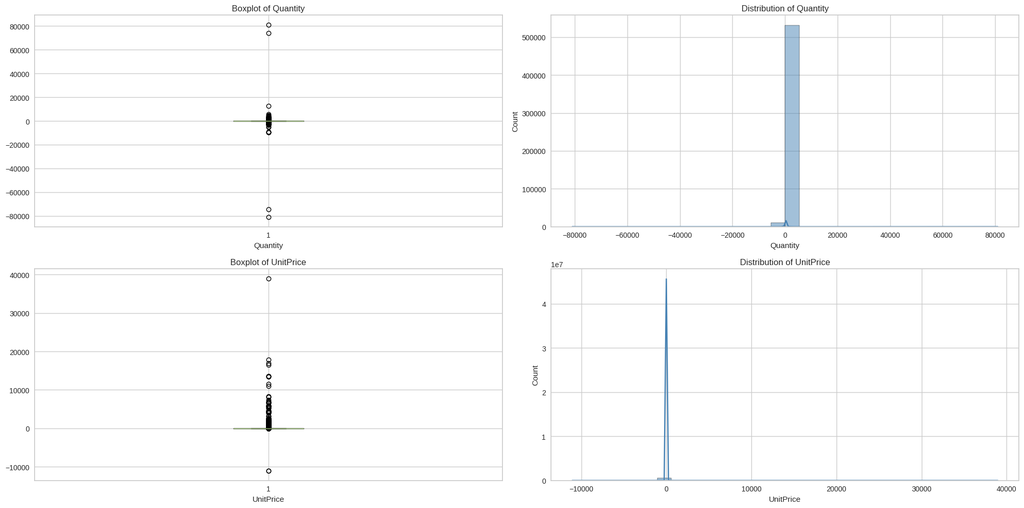

```python
# Define figure size
plt.figure(figsize=(20, 10))  # Increase height to accommodate both boxplots and distributions

columns_per_row = 2  # Number of columns per row
rows = 2 * ((len(ordata_numeric_columns) + columns_per_row - 1) // columns_per_row)  # Adjust rows for two subplots per variable

for i, col in enumerate(ordata_numeric_columns):
    # Boxplot (Top)
    plt.subplot(rows, columns_per_row, 2 * i + 1)
    plt.boxplot(ordata[col].dropna(), vert=True)  # Drop NaN for boxplot calculation
    plt.title(f'Boxplot of {col}')
    plt.xlabel(col)

    # Distribution Plot (Bottom)
    plt.subplot(rows, columns_per_row, 2 * i + 2)
    sns.histplot(ordata[col].dropna(), bins=30, color='steelblue', edgecolor='black', kde=True)
    plt.title(f'Distribution of {col}')
    plt.xlabel(col)

plt.tight_layout()
plt.show()
```

Key Observations:

**Quantity**

- **Boxplot Observations**:
  - Clear presence of **extreme outliers**, including both high positive and **negative values**.
  - Negative quantities suggest **product returns** or **data entry errors**.
  - The core distribution (IQR) is compressed near zero, indicating that most transactions involve small quantities.
- **Histogram Observations**:
  - Most values are concentrated around small positive quantities.
  - A **long tail** in both directions (especially negative) confirms a **heavily skewed distribution**.
  - The distribution is **non-normal** and has heavy tails, justifying the large number of IQR-detected outliers.

**UnitPrice**

- **Boxplot Observations**:
  - Several **high-value outliers** exist, as well as **negative prices**, which are likely data errors or refunds recorded incorrectly.
  - The interquartile range is narrow, meaning most unit prices are small (likely below £5).
- **Histogram Observations**:
  - A sharp spike at low values confirms the presence of **low-cost retail items**.
  - A **long positive tail** shows rare but extreme prices, potentially luxury items or price input mistakes.
  - Negative prices must be investigated or removed before analysis.

**Summary and Recommendations**

- Both features exhibit **severe outliers** that can **negatively impact clustering results**, especially in distance-based methods like **K-Means**.
- **Negative values** in both `Quantity` and `UnitPrice` are **illogical** in a typical sales context and must be addressed.
- Suggested actions before modeling:
  - **Remove or correct negative values.**
  - **Use IQR-based filtering or quantile clipping** to treat extreme outliers.
  - Optionally, consider **log-transforming** skewed variables (after removing negatives) for better scaling in clustering.

##### 3.2.2.1.2. Outlier Handling Methods (for Clustering)

To address the extreme values identified in the `Quantity` and `UnitPrice` variables, we apply two widely used outlier treatment techniques. These will result in two alternative versions of the dataset, which will later be used to train and compare clustering models:

- **Winsorization (dataset: `ordata_w`)**
- **IQR Method Removal (dataset: `ordata_r`)**

This approach allows us to evaluate the impact of each strategy on the clustering results, particularly on cluster cohesion and separation.

Truncation-Winsorization on ***ordata_w***. Winsorization caps extreme values to reduce the influence of outliers without removing any records.

**Implementation Steps:**

- For each numeric variable, values below the 1st percentile and above the 99th percentile are capped to those limits.
- Negative values for `Quantity` and `UnitPrice`, which are logically invalid, are removed after capping.

**✅ Pros:** Retains all observations, preserving the full customer base and reduces the distortion caused by extreme values in distance-based clustering (e.g., K-Means).  
**❌ Cons:** May still introduce artificial similarity across capped values and Residual skewness may persist, affecting scaling and cluster shapes.

IQR Method Removal on ***ordata_r***. The IQR method filters out extreme records that fall outside the normal interquartile range.

**Implementation Steps:**

- For each numeric column, compute Q1 and Q3.
- Remove any rows with values below Q1 − 1.5×IQR or above Q3 + 1.5×IQR.
- Additionally, remove rows with non-positive `Quantity` or `UnitPrice` values.

**✅ Pros:** Ensures a cleaner dataset for unsupervised learning and removes potential data entry errors and rare noise cases that may form artificial clusters.  
**❌ Cons:** Reduces dataset size, which may impact model robustness if a significant portion of the data is filtered. May exclude valid edge-case behaviors or niche customer types.

Both datasets will be retained and analyzed in parallel to understand how outlier handling influences the clustering results, especially regarding segment definitions, silhouette scores, and business interpretability.

```python
# Create copies
ordata_w = ordata.copy()  # Winsorized version
ordata_r = ordata.copy()  # IQR-based removal

# Select numeric columns (excluding ID-type fields)
ordata_numeric_columns = ordata.select_dtypes(include=[np.number]).columns.difference(['CustomerID'])

### 1. Winsorization (1% tails capped)
for col in ordata_numeric_columns:
    ordata_w[col] = winsorize(ordata_w[col], limits=[0.01, 0.01])

# Optional: remove impossible values (e.g., negative quantities/prices)
ordata_w = ordata_w[(ordata_w['Quantity'] > 0) & (ordata_w['UnitPrice'] > 0)]

### 2. IQR Method for Outlier Removal
def remove_outliers_iqr(df, column):
    Q1 = df[column].quantile(0.25)
    Q3 = df[column].quantile(0.75)
    IQR = Q3 - Q1
    lower = Q1 - 1.5 * IQR
    upper = Q3 + 1.5 * IQR
    return df[(df[column] >= lower) & (df[column] <= upper)]

# Apply IQR filter for each feature
for col in ordata_numeric_columns:
    ordata_r = remove_outliers_iqr(ordata_r, col)

# Optional: remove impossible values
ordata_r = ordata_r[(ordata_r['Quantity'] > 0) & (ordata_r['UnitPrice'] > 0)]
```

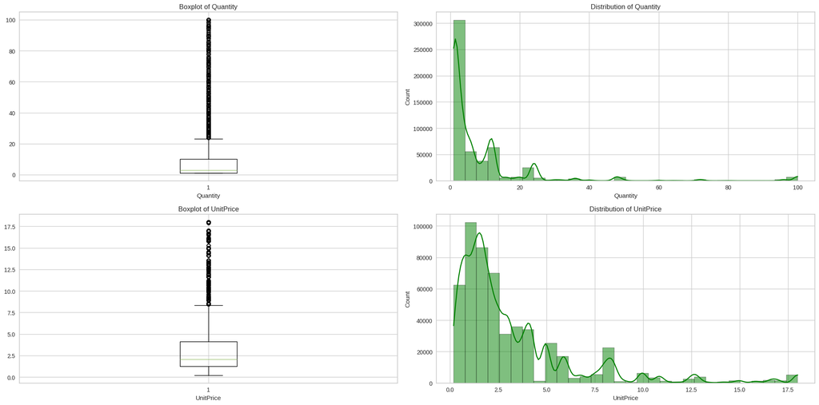

```python
# Define figure size
plt.figure(figsize=(20, 10))  # Increase height to accommodate both boxplots and distributions

columns_per_row = 2  # Number of columns per row
rows = 2 * ((len(ordata_numeric_columns) + columns_per_row - 1) // columns_per_row)  # Adjust rows for two subplots per variable

for i, col in enumerate(ordata_numeric_columns):
    # Boxplot (Top)
    plt.subplot(rows, columns_per_row, 2 * i + 1)
    plt.boxplot(ordata_w[col].dropna(), vert=True)  # Drop NaN for boxplot calculation
    plt.title(f'Boxplot of {col}')
    plt.xlabel(col)

    # Distribution Plot (Bottom)
    plt.subplot(rows, columns_per_row, 2 * i + 2)
    sns.histplot(ordata_w[col].dropna(), bins=30, color='green', edgecolor='black', kde=True)
    plt.title(f'Distribution of {col}')
    plt.xlabel(col)

plt.tight_layout()
plt.show()
```

***Visualization After Winsorization***

The boxplots and histograms of `Quantity` and `UnitPrice` after applying Winsorization reveal that the most extreme values have been successfully capped, resulting in more compact and stable distributions.

In the boxplot of `Quantity`, the data range is now more constrained, with a noticeable reduction in outlier spread. The values predominantly fall below 25 units, making the distribution more suitable for clustering. The corresponding histogram confirms a right-skewed distribution, but without the extreme long tails previously observed. Most transactions involve low quantities, which aligns with typical retail behavior.

For `UnitPrice`, the boxplot shows that abnormally high prices have been capped, producing a cleaner and more consistent range of values. The histogram also shows a concentrated distribution around low-price products (between £0 and £5), with reduced tail heaviness and smoother transitions.

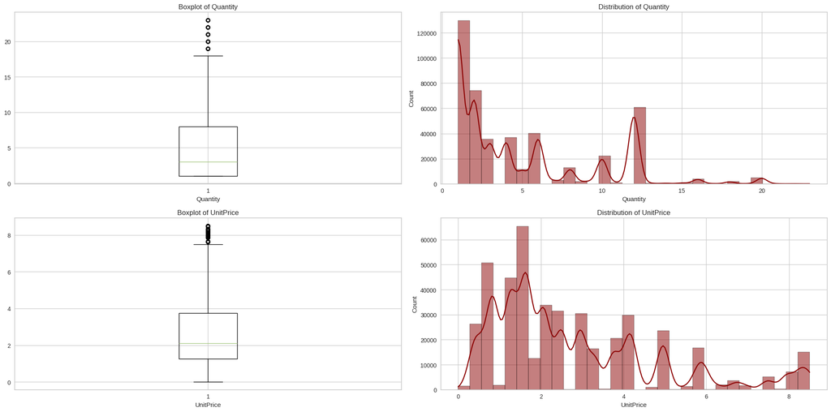

```python
# Define figure size
plt.figure(figsize=(20, 10))  # Increase height to accommodate both boxplots and distributions

columns_per_row = 2  # Number of columns per row
rows = 2 * ((len(ordata_numeric_columns) + columns_per_row - 1) // columns_per_row)  # Adjust rows for two subplots per variable

for i, col in enumerate(ordata_numeric_columns):
    # Boxplot (Top)
    plt.subplot(rows, columns_per_row, 2 * i + 1)
    plt.boxplot(ordata_r[col].dropna(), vert=True)  # Drop NaN for boxplot calculation
    plt.title(f'Boxplot of {col}')
    plt.xlabel(col)

    # Distribution Plot (Bottom)
    plt.subplot(rows, columns_per_row, 2 * i + 2)
    sns.histplot(ordata_r[col].dropna(), bins=30, color='darkred', edgecolor='black', kde=True)
    plt.title(f'Distribution of {col}')
    plt.xlabel(col)

plt.tight_layout()
plt.show()
```

***Visualization After IQR-Based Outlier Removal***

The boxplots and histograms of `Quantity` and `UnitPrice` after applying the IQR method show that the most extreme values have been removed, resulting in cleaner and more compact distributions.

In the boxplot of `Quantity`, nearly all previously observed extreme values have been eliminated. The distribution now appears more symmetrical, with the majority of data falling below 15 units. The corresponding histogram confirms a strong right skew but with a clearer and more focused concentration of values. This suggests more consistent customer behavior in terms of quantity purchased.

The boxplot of `UnitPrice` also shows a well-constrained value range, with no extremely high or negative values remaining. The data is now centered around a typical retail price, with a more balanced spread. The histogram demonstrates a well-defined peak between £1 and £3, with fewer fluctuations across the range.

Overall, the IQR method has effectively removed the extreme noise from the dataset. This improves the reliability of distance metrics for clustering and ensures that the analysis is focused on the typical behaviors of the majority of customers.

#### 3.2.2.2. Outlier Analysis in RFM dataset

##### 3.2.2.2.1. Initial Outlier Detection

```python
rfmdata
```

|  | CustomerID | Recency | Frequency | Monetary |
| --- | --- | --- | --- | --- |
| 0 | 12346.0 | 326 | 1 | 77183.60 |
| 1 | 12347.0 | 2 | 7 | 4310.00 |
| 2 | 12348.0 | 75 | 4 | 1797.24 |
| 3 | 12349.0 | 19 | 1 | 1757.55 |
| 4 | 12350.0 | 310 | 1 | 334.40 |
| ... | ... | ... | ... | ... |
| 4333 | 18280.0 | 278 | 1 | 180.60 |
| 4334 | 18281.0 | 181 | 1 | 80.82 |
| 4335 | 18282.0 | 8 | 2 | 178.05 |
| 4336 | 18283.0 | 4 | 16 | 2094.88 |
| 4337 | 18287.0 | 43 | 3 | 1837.28 |

4338 rows × 4 columns

```python
from scipy import stats
rfmdata_numeric_columns = rfmdata.select_dtypes(include=[np.number]).columns.difference(['CustomerID'])
rfmdata_outliers_summary = detect_outliers_summary(rfmdata, rfmdata_numeric_columns)

# Print outliers summary
for feature, stats in rfmdata_outliers_summary.items():
    if feature != 'unique_outliers_count':
        print(f"Feature: {feature}")
        print(f"  Z-Score Outliers Count: {stats['z_outliers_count']}")
        print(f"  IQR Outliers Count: {stats['iqr_outliers_count']}")
    else:
        print(f"\nTotal Unique Records with Outliers across RFM dataset Features: {stats}")
```

```
Feature: Frequency
  Z-Score Outliers Count: 53
  IQR Outliers Count: 285
Feature: Monetary
  Z-Score Outliers Count: 31
  IQR Outliers Count: 427
Feature: Recency
  Z-Score Outliers Count: 0
  IQR Outliers Count: 155

Total Unique Records with Outliers across RFM dataset Features: 628
```

Outliers were detected on the **RFM (Recency, Frequency, Monetary)** features using both the **Z-score** and **IQR (Interquartile Range)** methods. The `CustomerID` field was excluded, as it is an identifier and not meaningful for statistical analysis.

**Feature: Frequency**

- **Z-Score Outliers Count**: `53`  
  Records where the frequency of purchases deviates more than ±3 standard deviations from the mean, indicating unusually frequent buyers.
  - **IQR Outliers Count**: `285`

  A notable number of customers made significantly more purchases than typical, likely representing highly loyal or anomalous customers (e.g., resellers).

**Feature: Monetary**

- **Z-Score Outliers Count**: `31`  
  These records reflect customers who spent significantly more than average, potentially due to bulk or high-value purchases.
- **IQR Outliers Count**: `427`  
  Suggests the presence of a long-tailed distribution in customer spending behavior — possibly driven by outliers such as corporate clients or irregular buying patterns.

**Feature: Recency**

- **Z-Score Outliers Count**: `0`  
  No extreme values were detected based on standard deviation, indicating relatively stable recency patterns.
- **IQR Outliers Count**: `155`  
  Customers with extremely recent or outdated interactions were identified. These might reflect new, dormant, or lapsed clients.

**Total Unique Records with Outliers** A total of **628 unique customer records** in the RFM dataset contain at least one outlier in **Recency**, **Frequency**, or **Monetary** dimensions. This indicates that **~14%** of the RFM dataset (628 out of 4338 records) includes at least one statistically anomalous behavior that could affect clustering.

**Interpretation** The presence of outliers in the RFM dataset suggests:

- A **wide range of customer behaviors**, from high-frequency loyal buyers to low-activity or recent/dormant clients.
- **Monetary outliers** may point to strategic accounts or data inconsistencies that require further business interpretation.
- **Proper treatment of these outliers** (e.g., capping, transformation, or segmentation before clustering) is crucial to improve the robustness of segmentation algorithms such as K-Means or DBSCAN.

Lets see the boxplots for the RFM dataset

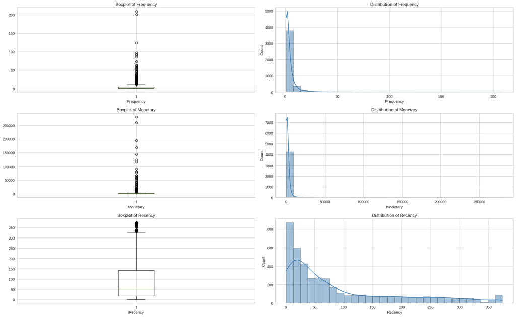

```python
# Define figure size
plt.figure(figsize=(20, 16))  # Increase height to accommodate both boxplots and distributions

columns_per_row = 2  # Number of columns per row
rows = 2 * ((len(rfmdata_numeric_columns) + columns_per_row - 1) // columns_per_row)  # Adjust rows for two subplots per variable

for i, col in enumerate(rfmdata_numeric_columns):
    # Boxplot (Top)
    plt.subplot(rows, columns_per_row, 2 * i + 1)
    plt.boxplot(rfmdata[col].dropna(), vert=True)  # Drop NaN for boxplot calculation
    plt.title(f'Boxplot of {col}')
    plt.xlabel(col)

    # Distribution Plot (Bottom)
    plt.subplot(rows, columns_per_row, 2 * i + 2)
    sns.histplot(rfmdata[col].dropna(), bins=30, color='steelblue', edgecolor='black', kde=True)
    plt.title(f'Distribution of {col}')
    plt.xlabel(col)

plt.tight_layout()
plt.show()
```

Before applying any transformations such as Winsorization or IQR-based outlier filtering, we visualized the RFM dataset to understand its distribution and detect potential outliers. This was done through boxplots and histograms for each variable: **Recency**, **Frequency**, and **Monetary**.

**Frequency**

- **Boxplot Insight**  
  The boxplot reveals that most customers have a **low purchase frequency** (between 1 and 5), while several extreme outliers go beyond 200 purchases. These outliers are clearly visible and spread far above the upper quartile.
- **Distribution Insight**  
  The histogram is **highly right-skewed**, showing that the majority of customers fall into the low-frequency range. A long tail of customers with high purchasing activity introduces significant skewness.
- **Conclusion**  
  The skewed nature and presence of outliers indicate the need for transformation. These values could otherwise **distort clustering results**, as they might pull centroids toward high-frequency customers.

**Monetary**

- **Boxplot Insight**  
  The Monetary feature shows the **widest spread** of all variables, with outliers reaching above **£250,000**. Most customers spend relatively little, but a small fraction contributes disproportionately to revenue.
- **Distribution Insight**  
  A **severely right-skewed** distribution is observed, typical in retail where **a few high-value customers** dominate overall revenue. The bulk of data is compressed at the lower end, making visualization and modeling difficult without transformation.
- **Conclusion**  
  This variable must be normalized or capped before clustering. If left untreated, **high-spending outliers** will dominate the segmentation model and obscure insights from regular customers.

**Recency**

- **Boxplot Insight**  
  Recency has **fewer extreme outliers** compared to Frequency and Monetary. Most customers fall under 150 days, although some go up to 360 days without activity.
- **Distribution Insight**  
  The histogram is **moderately right-skewed**, but not as extreme. A clear descending curve shows that more customers are active recently, with fewer inactive for long periods.
- **Conclusion**  
  Although more balanced, Recency still benefits from outlier treatment to **align the scale** with the other RFM variables.

**Summary**

- All three RFM dimensions contain outliers, particularly **Monetary** and **Frequency**.
- The **scales and distributions are not uniform**, introducing risks when using distance-based algorithms like **K-Means**.
- Applying **outlier treatment methods** (e.g., IQR filtering or Winsorization) will help reduce skewness, normalize influence across features, and improve the quality of segmentation results.

**Next step:** We will proceed to remove or cap outliers based on IQR/Winsorization thresholds to enhance clustering performance.

##### 3.2.2.2.2. Outlier Handling Methods (for Clustering)

```python
from scipy.stats.mstats import winsorize

# Create copies for each outlier treatment strategy
rfmdata_w = rfmdata.copy()  # Winsorized version
rfmdata_r = rfmdata.copy()  # IQR-based removal

# Select numeric columns (excluding customer identifier if present)
rfm_numeric_columns = rfmdata.select_dtypes(include=[np.number]).columns.difference(['CustomerID'])

# --- 1. Winsorization (Capping at 1% tails) ---
for col in rfm_numeric_columns:
    rfmdata_w[col] = winsorize(rfmdata_w[col], limits=[0.01, 0.01])

# --- 2. IQR Method for Outlier Removal ---
def remove_outliers_iqr(df, column):
    Q1 = df[column].quantile(0.25)
    Q3 = df[column].quantile(0.75)
    IQR = Q3 - Q1
    lower = Q1 - 1.5 * IQR
    upper = Q3 + 1.5 * IQR
    return df[(df[column] >= lower) & (df[column] <= upper)]

# Apply IQR filter for each RFM feature
for col in rfm_numeric_columns:
    rfmdata_r = remove_outliers_iqr(rfmdata_r, col)
```

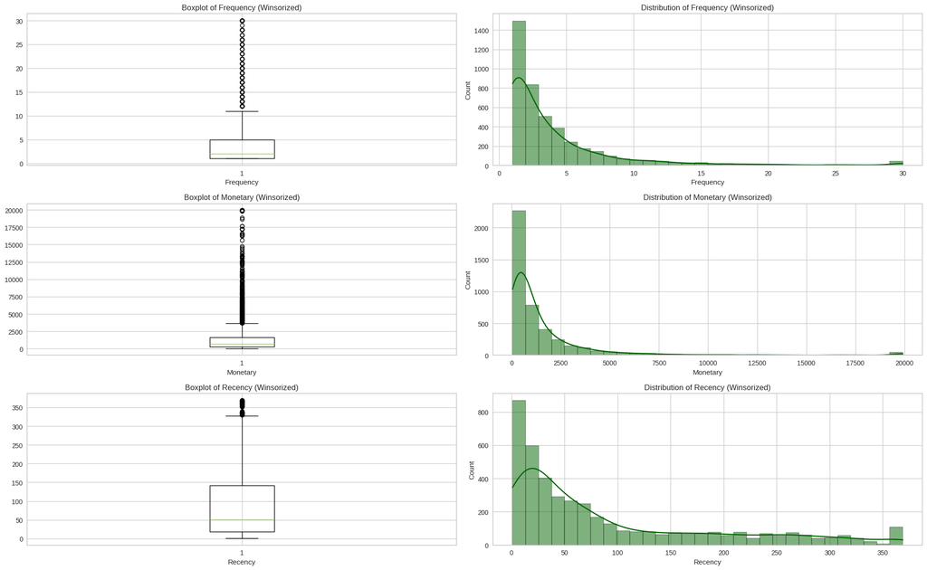

```python
# Define figure size
plt.figure(figsize=(20, 16))

columns_per_row = 2
rfm_numeric_columns = rfmdata_w.select_dtypes(include=[np.number]).columns.difference(['CustomerID'])
rows = 2 * ((len(rfm_numeric_columns) + columns_per_row - 1) // columns_per_row)

for i, col in enumerate(rfm_numeric_columns):
    # Boxplot
    plt.subplot(rows, columns_per_row, 2 * i + 1)
    plt.boxplot(rfmdata_w[col].dropna(), vert=True)
    plt.title(f'Boxplot of {col} (Winsorized)')
    plt.xlabel(col)

    # Histogram with KDE
    plt.subplot(rows, columns_per_row, 2 * i + 2)
    sns.histplot(rfmdata_w[col].dropna(), bins=30, color='darkgreen', edgecolor='black', kde=True)
    plt.title(f'Distribution of {col} (Winsorized)')
    plt.xlabel(col)

plt.tight_layout()
plt.show()
```

After applying Winsorization to the transactional dataset, the RFM features show a more controlled and stable behavior, especially regarding the reduction of extreme outliers.

In the case of **Frequency**, the boxplot indicates a much tighter range compared to the original data. Outliers beyond 30 transactions have been capped, reducing their influence on downstream clustering. The histogram remains right-skewed, reflecting the typical pattern of many customers purchasing only once or twice, but without the distracting long tail.

For **Monetary**, Winsorization has greatly reduced the spread of extreme values, as shown in the boxplot where values above 20,000 are no longer present. The distribution is still skewed to the right, but more interpretable, with most customers concentrated below 2,000 in spend. This smoother scale will improve the behavior of algorithms sensitive to distance.

**Recency** displays only a subtle change. Since it originally had fewer extreme outliers, the effect of Winsorization is less pronounced. The histogram still shows a steep decay with most recent purchases occurring within the last 50 days, which is expected in customer behavior analysis.

Overall, this transformation retains all customer records while reducing the distortion caused by outlier values. The data is now in better shape for clustering, allowing distance-based methods like K-Means to work more effectively and produce meaningful customer segments.

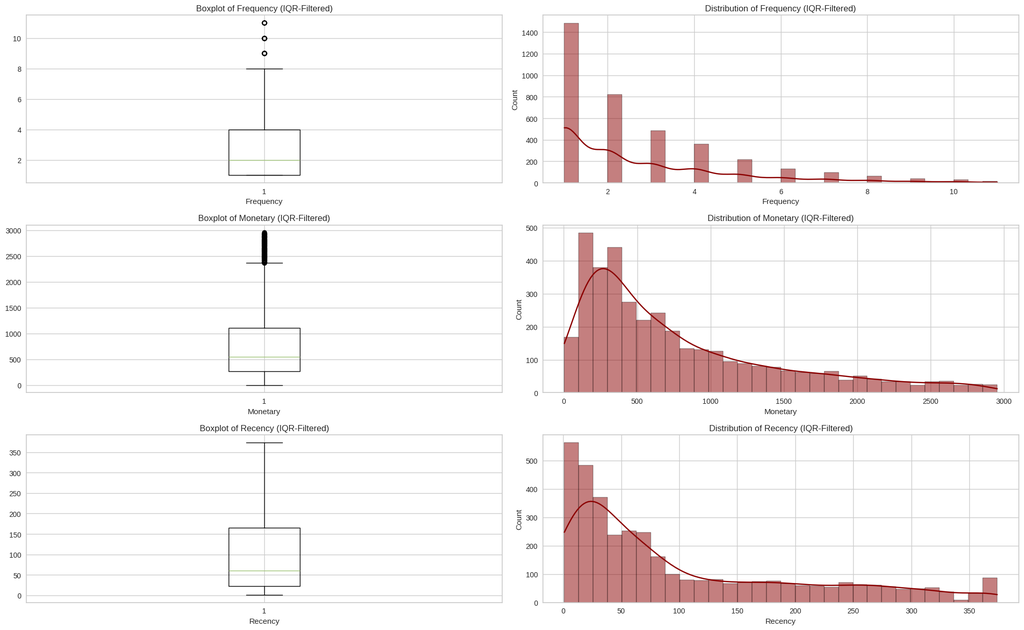

```python
# Define figure size
plt.figure(figsize=(20, 16))

columns_per_row = 2
rfm_numeric_columns = rfmdata_r.select_dtypes(include=[np.number]).columns.difference(['CustomerID'])
rows = 2 * ((len(rfm_numeric_columns) + columns_per_row - 1) // columns_per_row)

for i, col in enumerate(rfm_numeric_columns):
    # Boxplot
    plt.subplot(rows, columns_per_row, 2 * i + 1)
    plt.boxplot(rfmdata_r[col].dropna(), vert=True)
    plt.title(f'Boxplot of {col} (IQR-Filtered)')
    plt.xlabel(col)

    # Histogram with KDE
    plt.subplot(rows, columns_per_row, 2 * i + 2)
    sns.histplot(rfmdata_r[col].dropna(), bins=30, color='darkred', edgecolor='black', kde=True)
    plt.title(f'Distribution of {col} (IQR-Filtered)')
    plt.xlabel(col)

plt.tight_layout()
plt.show()
```

The RFM features after applying the IQR method for outlier removal show a more compressed and representative view of customer behavior by eliminating extreme values entirely from the dataset.

In the case of **Frequency**, the boxplot reveals a notably narrower range, with most customers exhibiting repeat purchases between 1 and 4 times. The histogram displays a steep drop-off after 2 purchases, indicating that a significant portion of customers are relatively infrequent buyers. The removal of outliers helps reduce skewness, though some long-tail behavior remains.

The **Monetary** distribution is also substantially improved. The boxplot displays a more compact interquartile range and a much smaller spread of upper values. The corresponding histogram shows a right-skewed but smoother distribution, with most customers spending under 1,000 units. This reflects more realistic and homogeneous customer spending behavior.

Overall, the IQR filtering process has removed the most extreme purchase patterns, leading to a more stable and focused dataset. Although it sacrifices a small portion of data points, the resulting dataset is better tailored for clustering algorithms, improving accuracy and segment interpretability.

## 3.3. Features Graphical Analysis

### 3.3.1. Features Graphical Analysis on RAW Dataset

This section provides an exploratory graphical analysis of the raw transactional dataset before any feature engineering or clustering. It highlights how revenue is distributed across countries, identifies top-performing products, and examines time-based trends. These insights provide context for later steps such as RFM feature engineering and customer segmentation.

#### 3.3.1.1. Key Revenue and Product Insights (RAW Dataset)

We begin by analyzing which countries and products contribute most to total revenue. This helps identify high-value regions and items that dominate sales volume and profitability.

- Revenue by Country: Shows how total revenue is distributed across all countries.
- Top Products by Quantity: Identifies the items with the highest number of units sold.
- Top Products by Revenue: Highlights items that generate the most revenue, which may differ from the top-sold products.

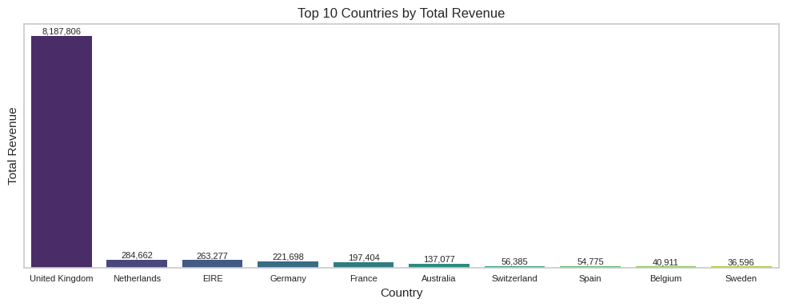

```python
# Prepare data
ordata_G = ordata.copy()
ordata_G['TotalPrice'] = ordata_G['Quantity'] * ordata_G['UnitPrice']

# Aggregate revenue by country
country_revenue = ordata_G.groupby('Country')['TotalPrice'].sum().sort_values(ascending=False).head(10).reset_index()

# Plot
plt.figure(figsize=(10,4))
ax = sns.barplot(data=country_revenue, x='Country', y='TotalPrice', hue='Country', palette='viridis', legend=False)

# Add values on top
for i, value in enumerate(country_revenue['TotalPrice']):
    ax.text(i, value, f'{value:,.0f}', ha='center', va='bottom', fontsize=8)

plt.title('Top 10 Countries by Total Revenue')
plt.ylabel('Total Revenue')
plt.xlabel('Country')
plt.xticks(fontsize=8, rotation=0)
ax.set_yticks([])  # Remove Y ticks
plt.tight_layout()
plt.show()
```

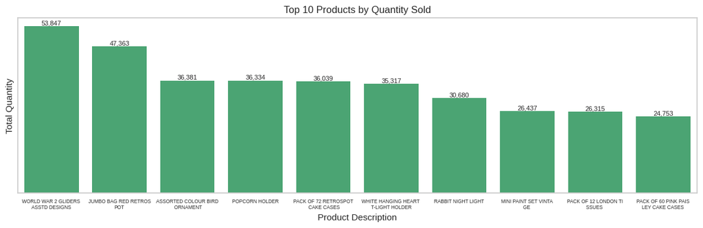

```python
# Top products by quantity
top_products = ordata_G.groupby('Description')['Quantity'].sum().sort_values(ascending=False).head(10).reset_index()

# Plot
plt.figure(figsize=(12,4))
ax = sns.barplot(data=top_products, x='Description', y='Quantity', color='mediumseagreen')

# Wrap labels
def wrap_labels(ax, df, col='Description', width=20):
    labels = []
    for i in ax.get_xticks():
        text = df[col].iloc[i]
        wrapped = '\n'.join([text[j:j+width] for j in range(0, len(text), width)])
        labels.append(wrapped)
    ax.set_xticks(range(len(df)))
    ax.set_xticklabels(labels)
    ax.tick_params(axis='x', labelsize=6)

wrap_labels(ax, top_products)

# Add values on top
for i, value in enumerate(top_products['Quantity']):
    ax.text(i, value, f'{value:,.0f}', ha='center', va='bottom', fontsize=8)

plt.title('Top 10 Products by Quantity Sold')
plt.ylabel('Total Quantity')
plt.xlabel('Product Description')
ax.set_yticks([])  # Remove Y ticks
plt.tight_layout()
plt.show()
```

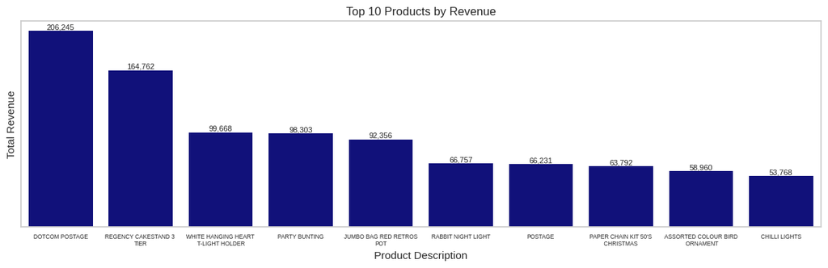

```python
# Top products by revenue
top_products_revenue = ordata_G.groupby('Description')["TotalPrice"].sum().sort_values(ascending=False).head(10).reset_index()

# Plot
plt.figure(figsize=(12,4))
ax = sns.barplot(data=top_products_revenue, x='Description', y='TotalPrice', color='darkblue')

# Wrap labels
wrap_labels(ax, top_products_revenue)

# Add values on top
for i, value in enumerate(top_products_revenue['TotalPrice']):
    ax.text(i, value, f'{value:,.0f}', ha='center', va='bottom', fontsize=8)

plt.title('Top 10 Products by Revenue')
plt.ylabel('Total Revenue')
plt.xlabel('Product Description')
ax.set_yticks([])  # Remove Y ticks
plt.tight_layout()
plt.show()
```

**Notes on the Products in the Top Revenue Chart**

The chart above correctly represents the products with the highest total revenue. However, it is important to note that **some of these items are not physical products sold to customers** but rather administrative or logistical charges recorded in the invoice.

For instance, **`DOTCOM POSTAGE`** and **`POSTAGE`** appear in the list because they represent **shipping and handling charges associated with online orders**, not actual goods. These entries are included in the dataset as products but in reality reflect service fees (such as delivery costs) instead of tangible merchandise.

While this section intentionally keeps these records to reflect the **overall revenue billed by the company**, analysts should be aware that their inclusion can slightly distort the interpretation of product performance. For more precise product-based analyses (e.g., profitability or demand forecasting), it may be appropriate to filter out such non-product items.

#### 3.3.1.2. Time-Based Analysis (RAW Dataset)

Next, we explore temporal patterns in sales to uncover seasonality and behavioral trends. These include monthly revenue trends, day-of-week activity, and hourly transaction patterns. Such insights can be leveraged for marketing timing, inventory planning, and operational decisions.

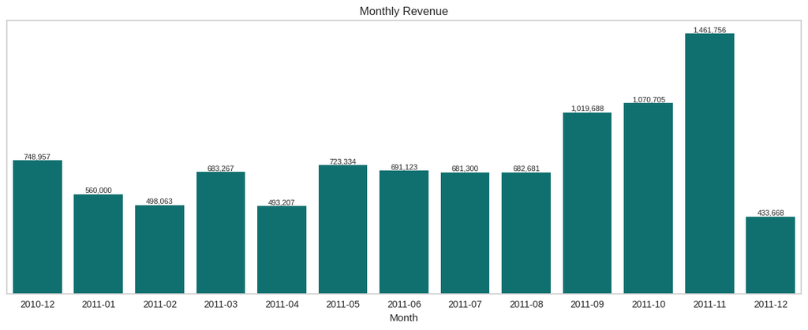

```python
# Copy and preprocess
ordata_G = ordata.copy()
ordata_G["InvoiceDate"] = pd.to_datetime(ordata_G["InvoiceDate"])
ordata_G["TotalPrice"] = ordata_G["Quantity"] * ordata_G["UnitPrice"]

# Create time features
ordata_G["Month"] = ordata_G["InvoiceDate"].dt.to_period("M")
ordata_G["DayOfWeek"] = ordata_G["InvoiceDate"].dt.day_name()
ordata_G["Hour"] = ordata_G["InvoiceDate"].dt.hour

# Monthly stats
monthly_stats = ordata_G.groupby("Month").agg({"TotalPrice": "sum", "Quantity": "sum"}).reset_index()
monthly_stats["Month"] = monthly_stats["Month"].astype(str)

# --- Monthly Revenue ---
plt.figure(figsize=(12,5))
ax = sns.barplot(data=monthly_stats, x="Month", y="TotalPrice", color="teal")
for p in ax.patches:
    ax.annotate(f'{p.get_height():,.0f}', (p.get_x() + p.get_width() / 2., p.get_height()),
                ha='center', va='bottom', fontsize=8)
ax.set_ylabel("")
ax.set_yticks([])
plt.title("Monthly Revenue")
plt.xlabel("Month")
plt.xticks(rotation=0)
plt.tight_layout()
plt.show()
```

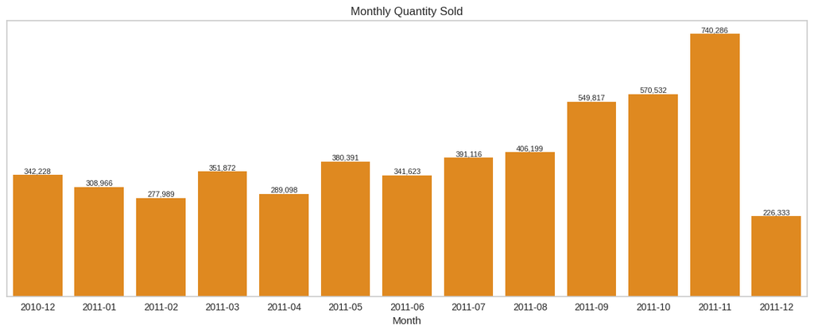

```python
# --- Monthly Quantity ---
plt.figure(figsize=(12,5))
ax = sns.barplot(data=monthly_stats, x="Month", y="Quantity", color="darkorange")
for p in ax.patches:
    ax.annotate(f'{p.get_height():,.0f}', (p.get_x() + p.get_width() / 2., p.get_height()),
                ha='center', va='bottom', fontsize=8)
ax.set_ylabel("")
ax.set_yticks([])
plt.title("Monthly Quantity Sold")
plt.xlabel("Month")
plt.xticks(rotation=0)
plt.tight_layout()
plt.show()
```

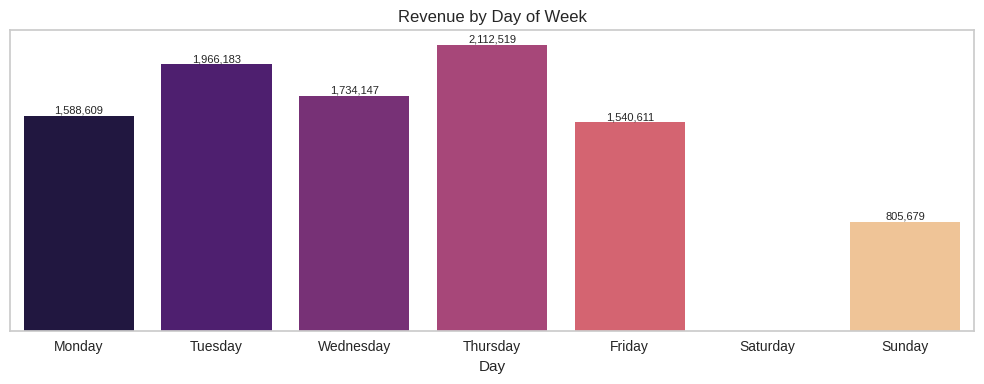

```python
# --- Revenue by Day of Week ---
day_stats = ordata_G.groupby("DayOfWeek")["TotalPrice"].sum().reindex([
    "Monday", "Tuesday", "Wednesday", "Thursday", "Friday", "Saturday", "Sunday"
]).reset_index()

plt.figure(figsize=(10,4))
ax = sns.barplot(data=day_stats, x="DayOfWeek", y="TotalPrice", hue="DayOfWeek", palette="magma", legend=False)
for p in ax.patches:
    ax.annotate(f'{p.get_height():,.0f}', (p.get_x() + p.get_width() / 2., p.get_height()),
                ha='center', va='bottom', fontsize=8)
ax.set_ylabel("")
ax.set_yticks([])
plt.title("Revenue by Day of Week")
plt.xlabel("Day")
plt.xticks(rotation=0)
plt.tight_layout()
plt.show()
```

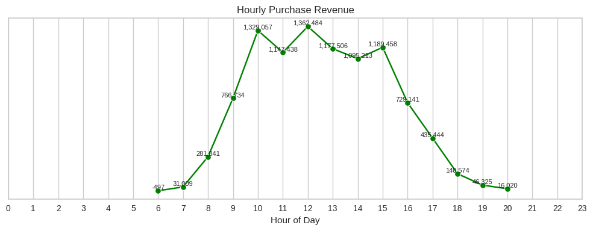

```python
# --- Revenue by Hour of Day ---
hourly_stats = ordata_G.groupby("Hour")["TotalPrice"].sum().reset_index()

plt.figure(figsize=(10,4))
ax = sns.lineplot(data=hourly_stats, x="Hour", y="TotalPrice", marker='o', color="green")
for x, y in zip(hourly_stats["Hour"], hourly_stats["TotalPrice"]):
    plt.text(x, y, f'{y:,.0f}', ha='center', va='bottom', fontsize=8)
ax.set_ylabel("")
ax.set_yticks([])
plt.title("Hourly Purchase Revenue")
plt.xlabel("Hour of Day")
plt.xticks(range(0,24))
plt.tight_layout()
plt.show()
```

***Monthly Quantity Sold*** The quantity of items sold monthly follows a similar pattern to revenue, peaking in **November 2011** with **740,286 units sold**. The first quarter shows relatively low sales volumes, but the trend increases steadily from mid-year, reinforcing the seasonal demand pattern.

### 3.3.2. Features Graphical Analysis on RFM Dataset

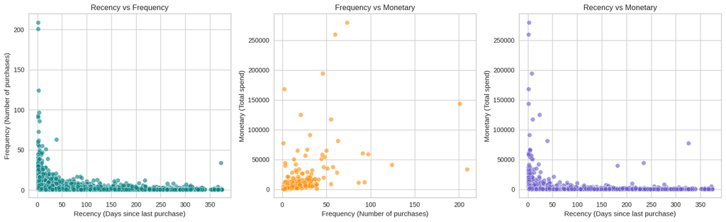

```python
rfmdata_G = rfmdata.copy()

# Pairwise scatterplots
plt.figure(figsize=(16, 5))

# Recency vs Frequency
plt.subplot(1, 3, 1)
sns.scatterplot(data=rfmdata_G, x='Recency', y='Frequency', color='teal', alpha=0.6)
plt.title('Recency vs Frequency')
plt.xlabel('Recency (Days since last purchase)')
plt.ylabel('Frequency (Number of purchases)')

# Frequency vs Monetary
plt.subplot(1, 3, 2)
sns.scatterplot(data=rfmdata_G, x='Frequency', y='Monetary', color='darkorange', alpha=0.6)
plt.title('Frequency vs Monetary')
plt.xlabel('Frequency (Number of purchases)')
plt.ylabel('Monetary (Total spend)')

# Recency vs Monetary
plt.subplot(1, 3, 3)
sns.scatterplot(data=rfmdata_G, x='Recency', y='Monetary', color='slateblue', alpha=0.6)
plt.title('Recency vs Monetary')
plt.xlabel('Recency (Days since last purchase)')
plt.ylabel('Monetary (Total spend)')

plt.tight_layout()
plt.show()
```

This section presents scatter plots that visualize relationships between the three key **RFM** features: **Recency**, **Frequency**, and **Monetary**. These plots help uncover behavioral patterns among customers.

***Recency vs Frequency***  
**X-axis:** Recency (Days since last purchase)  
**Y-axis:** Frequency (Number of purchases)

Customers who purchased **recently** tend to buy **more frequently**. There is a clear **negative relationship**, where customers with **high recency** (long time since last purchase) tend to have **low frequency**.  
This suggests that **loyal customers** buy more often and have made purchases more recently, while those who haven't engaged in a long time are less valuable from a frequency perspective.

***Frequency vs Monetary***  
**X-axis:** Frequency (Number of purchases)  
**Y-axis:** Monetary (Total amount spent)

There is a **positive correlation** — customers who buy more often tend to spend more. However, we observe some **high-value customers with low purchase frequency**, indicating that **some customers place large but infrequent orders**.  
This relationship highlights **two profitable segments**: high-frequency, high-spending loyalists, and occasional big spenders who may be ideal for targeted retention strategies.

***Recency vs Monetary***  
**X-axis:** Recency (Days since last purchase)  
**Y-axis:** Monetary (Total amount spent)

This plot shows that **recent buyers tend to be the highest spenders**, while those who haven't purchased in a long time generally have lower total spend.  
The implication is that **customer value diminishes with inactivity**, reinforcing the importance of engaging customers before they churn.

# 4. Clustering Analysis

## 4.1. Final Dataset Creation for Clustering

Before performing clustering algorithms, we prepared multiple variants of the RFM dataset to evaluate how different outlier-handling and scaling techniques affect segmentation performance. This step ensures that we can choose the most robust, clean, and scalable version of the data for downstream modeling.

Below is a summary of all RFM datasets created:

[output not shown]

```python
def create_rfm(df):
    """
    Generate RFM features from raw or preprocessed transactional data.

    Parameters:
        df (pd.DataFrame): Transactional data with columns ['CustomerID', 'InvoiceDate', 'Quantity', 'UnitPrice', 'InvoiceNo']

    Returns:
        pd.DataFrame: RFM table with columns ['CustomerID', 'Recency', 'Frequency', 'Monetary']
    """
    import pandas as pd
    import numpy as np

    # 1. Copy and clean the data
    data = df.copy()
    data = data.dropna(subset=["CustomerID"])
    data = data[(data["Quantity"] > 0) & (data["UnitPrice"] > 0)]
    data["InvoiceDate"] = pd.to_datetime(data["InvoiceDate"])

    # 2. Reference date (day after last invoice)
    reference_date = data["InvoiceDate"].max() + pd.Timedelta(days=1)

    # 3. RFM computation
    rfm = data.groupby("CustomerID").agg({
        "InvoiceDate": lambda x: (reference_date - x.max()).days,       # Recency
        "InvoiceNo": "nunique",                                         # Frequency
        "Quantity": lambda x: np.sum(x * data.loc[x.index, "UnitPrice"])  # Monetary
    }).reset_index()

    rfm.columns = ["CustomerID", "Recency", "Frequency", "Monetary"]
    return rfm
```

```python
# -------------------------------
# Step 1: Create Raw Variants
# -------------------------------
ordata_w = ordata.copy()
ordata_r = ordata.copy()

numeric_cols = ordata.select_dtypes(include=[np.number]).columns.difference(['CustomerID'])

# Winsorization
for col in numeric_cols:
    ordata_w[col] = winsorize(ordata_w[col], limits=[0.01, 0.01])
ordata_w = ordata_w[(ordata_w['Quantity'] > 0) & (ordata_w['UnitPrice'] > 0)]

# IQR Removal
def remove_outliers_iqr(df, column):
    Q1 = df[column].quantile(0.25)
    Q3 = df[column].quantile(0.75)
    IQR = Q3 - Q1
    lower = Q1 - 1.5 * IQR
    upper = Q3 + 1.5 * IQR
    return df[(df[column] >= lower) & (df[column] <= upper)]

for col in numeric_cols:
    ordata_r = remove_outliers_iqr(ordata_r, col)
ordata_r = ordata_r[(ordata_r['Quantity'] > 0) & (ordata_r['UnitPrice'] > 0)]

# -------------------------------
# Step 2: Create RFM Variants
# -------------------------------
rfmdata     = create_rfm(ordata)
rfmdata_w   = create_rfm(ordata_w)
rfmdata_r   = create_rfm(ordata_r)
rfmdata_bw  = create_rfm(ordata_w)
rfmdata_br  = create_rfm(ordata_r)

# -------------------------------
# Step 3: Create Scaled RFM Versions (Excluding CustomerID)
# -------------------------------
def scale_rfm(df):
    scaler = MinMaxScaler()
    rfm_features = ['Recency', 'Frequency', 'Monetary']
    scaled = scaler.fit_transform(df[rfm_features])
    scaled_df = pd.DataFrame(scaled, columns=rfm_features)
    scaled_df['CustomerID'] = df['CustomerID'].values
    return scaled_df[['CustomerID'] + rfm_features]

rfmdata_S     = scale_rfm(rfmdata)
rfmdata_w_S   = scale_rfm(rfmdata_w)
rfmdata_r_S   = scale_rfm(rfmdata_r)
rfmdata_bw_S  = scale_rfm(rfmdata_bw)
rfmdata_br_S  = scale_rfm(rfmdata_br)
```

## 4.2. Number of Clusters initial Inference

Before applying clustering algorithms, it is essential to estimate the optimal number of clusters (`k`). This section uses two widely accepted methods: the **Elbow Method** and the **Silhouette Score**. These techniques guide us in selecting a `k` that balances model performance and interpretability.

### 4.2.1. Clusters Inference with Elbow Method

The **Elbow Method** is a widely used technique for identifying the optimal number of clusters (**k**) in unsupervised learning, particularly in **K-Means clustering**. The core idea is to evaluate how the total **Within-Cluster Sum of Squares (WSS)** changes as the number of clusters increases.

***What is WSS?***

The **Within-Cluster Sum of Squares (WSS)** measures the compactness of the clusters, i.e., how close the data points in a cluster are to the cluster centroid. It is computed as the sum of the squared Euclidean distances between each point and the centroid of its cluster.

***WSS Formula***

$WSS = \sum_{i=1}^{k} \sum_{x_j \in C_i} ||x_j - \mu_i||^2$

Where:

- $(k)$ is the number of clusters
- $C_i$ is the set of points in cluster ( i )
- $\mu_i$ is the centroid of cluster ( i )
- $x_j$ is an observation in cluster ( i )
- $||x_j - \mu_i||^2$ is the squared distance between a point and its cluster centroid

***How the Elbow Method Works***

1. Run K-Means clustering on the dataset for a range of ( k ) values (e.g., 1 to 10).
2. For each ( k ), compute the WSS.
3. Plot ( k ) against WSS to observe the trend.
4. The "elbow" point (where the WSS starts to decrease more slowly) suggests the optimal number of clusters. This is the point where adding more clusters yields diminishing returns.

***Why It Works***

The elbow represents the point at which increasing the number of clusters beyond it results in only marginal gains in cluster compactness. Selecting ( k ) at the elbow helps avoid overfitting while capturing the main structure in the data.

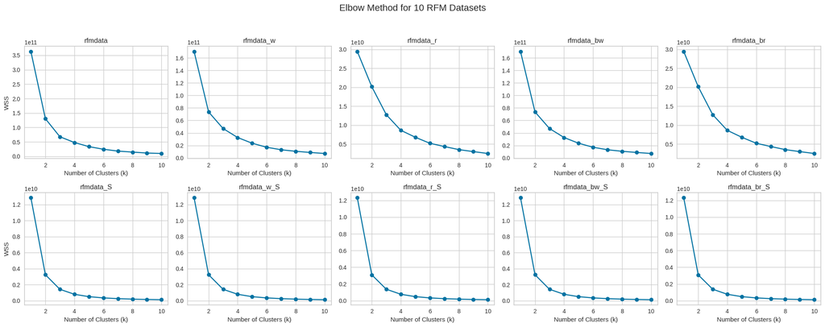

```python
# Assuming your 10 datasets are already defined and contain at least 10 rows each
dataset_names = [
    "rfmdata", "rfmdata_w", "rfmdata_r", "rfmdata_bw", "rfmdata_br",
    "rfmdata_S", "rfmdata_w_S", "rfmdata_r_S", "rfmdata_bw_S", "rfmdata_br_S"
]

dataset_list = [
    rfmdata, rfmdata_w, rfmdata_r, rfmdata_bw, rfmdata_br,
    rfmdata_S, rfmdata_w_S, rfmdata_r_S, rfmdata_bw_S, rfmdata_br_S
]

# Initialize subplot grid
fig, axs = plt.subplots(2, 5, figsize=(20, 8))
fig.suptitle("Elbow Method for 10 RFM Datasets", fontsize=16)

# Loop over each dataset and compute WSS for K = 1 to 10
for idx, (name, data) in enumerate(zip(dataset_names, dataset_list)):
    wss = []
    max_k = min(10, len(data))  # Avoid exceeding dataset size

    for k in range(1, max_k + 1):
        kmeans = KMeans(n_clusters=k, n_init=10, random_state=42)
        kmeans.fit(data)
        wss.append(kmeans.inertia_)

    ax = axs[idx // 5, idx % 5]
    ax.plot(range(1, max_k + 1), wss, marker='o')
    ax.set_title(name)
    ax.set_xlabel("Number of Clusters (k)")
    ax.set_ylabel("WSS" if idx % 5 == 0 else "")  # Only leftmost plots get Y label
    ax.grid(True)

plt.tight_layout(rect=[0, 0, 1, 0.95])
plt.show()
```

The graphs below display the WSS values for `k=1` to `k=10` for each of the following datasets, in the specified order:

| Dataset | Elbow Clarity | Suggested k | Comments |
| --- | --- | --- | --- |
| **rfmdata** | Clear | **3** | Sharp drop between k=1 and k=3, then flattening. |
| **rfmdata_w** | Clear | **3** | Similar elbow at k=3, winsorization preserves structure. |
| **rfmdata_r** | Clear | **3–4** | Slightly softer elbow but still visible near k=3 or 4. |
| **rfmdata_bw** | Clear | **3** | Elbow around 3, similar to `rfmdata_w`. |
| **rfmdata_br** | Clear | **3–4** | Elbow visible but smoother; suggests 3 or 4 clusters. |
| **rfmdata_S** | Clear | **3** | Elbow sharp at 3, scaling improves shape. |
| **rfmdata_w_S** | Clear | **3** | Very similar to `rfmdata_S`, robust structure. |
| **rfmdata_r_S** | Clear | **3–4** | Elbow around 3–4 again, slightly smoother. |
| **rfmdata_bw_S** | Clear | **3** | Best defined elbow, scaling + capping works well. |
| **rfmdata_br_S** | Clear | **3** | Consistent elbow at 3, clean dataset with scaling. |

### 4.2.2. Clusters Inference with Silhouette Method

The **Silhouette Method** evaluates the quality of clustering by measuring how well each data point lies within its cluster compared to other clusters.

For each sample `i`:

- Let $a(i)$ be the mean intra-cluster distance (average distance between `i` and all other points in the same cluster).
- Let $b(i)$ be the mean nearest-cluster distance (lowest average distance between `i` and points in the nearest different cluster).
- The **silhouette score $s(i)$** is calculated as:

$s(i) = \frac{b(i) - a(i)}{\max(a(i), b(i))}$

- Values range from **-1 to +1**:
  - `+1`: Perfect match to its cluster, far from others.
  - `0`: On the decision boundary.
  - `-1`: Wrongly assigned to the current cluster.

The **average silhouette score** across all samples indicates clustering quality for a given number of clusters `k`.

> Higher average silhouette score = better-defined clusters.

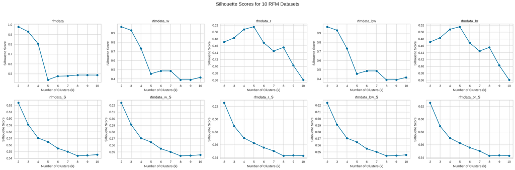

```python
# List of dataset names and corresponding actual dataframes
dataset_names = [
    'rfmdata', 'rfmdata_w', 'rfmdata_r', 'rfmdata_bw', 'rfmdata_br',
    'rfmdata_S', 'rfmdata_w_S', 'rfmdata_r_S', 'rfmdata_bw_S', 'rfmdata_br_S'
]

# Assume all datasets are stored as pandas DataFrames in a dictionary
# Example: rfm_datasets['rfmdata'] = <DataFrame>
rfm_datasets = {
    'rfmdata': rfmdata,
    'rfmdata_w': rfmdata_w,
    'rfmdata_r': rfmdata_r,
    'rfmdata_bw': rfmdata_bw,
    'rfmdata_br': rfmdata_br,
    'rfmdata_S': rfmdata_S,
    'rfmdata_w_S': rfmdata_w_S,
    'rfmdata_r_S': rfmdata_r_S,
    'rfmdata_bw_S': rfmdata_bw_S,
    'rfmdata_br_S': rfmdata_br_S,
}

# Plotting
fig, axes = plt.subplots(2, 5, figsize=(24, 8))
fig.suptitle("Silhouette Scores for 10 RFM Datasets", fontsize=16)

for i, name in enumerate(dataset_names):
    row, col = divmod(i, 5)
    ax = axes[row, col]
    data = rfm_datasets[name]

    silhouette_avgs = []
    k_range = range(2, 11)

    for k in k_range:
        model = KMeans(n_clusters=k, random_state=42)
        labels = model.fit_predict(data)
        score = silhouette_score(data, labels)
        silhouette_avgs.append(score)

    ax.plot(k_range, silhouette_avgs, marker='o')
    ax.set_title(name)
    ax.set_xlabel('Number of Clusters (k)')
    ax.set_ylabel('Silhouette Score')
    ax.grid(True)

plt.tight_layout(rect=[0, 0, 1, 0.95])
plt.show()
```

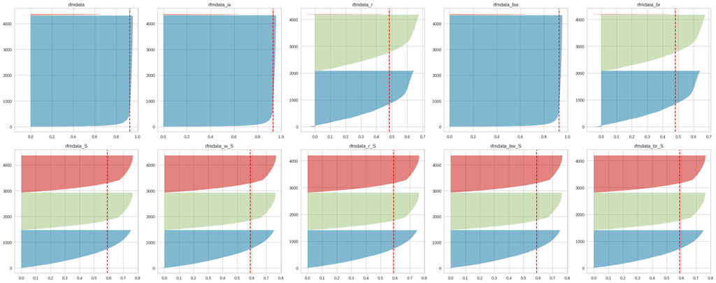

```python
datasets = [
    rfmdata, rfmdata_w, rfmdata_r, rfmdata_bw, rfmdata_br,
    rfmdata_S, rfmdata_w_S, rfmdata_r_S, rfmdata_bw_S, rfmdata_br_S
]

dataset_names = [
    "rfmdata", "rfmdata_w", "rfmdata_r", "rfmdata_bw", "rfmdata_br",
    "rfmdata_S", "rfmdata_w_S", "rfmdata_r_S", "rfmdata_bw_S", "rfmdata_br_S"
]

fig, axes = plt.subplots(nrows=2, ncols=5, figsize=(25, 10))
axes = axes.flatten()

for i, (data, name) in enumerate(zip(datasets, dataset_names)):
    ax = axes[i]
    model = KMeans(n_clusters=3, random_state=42)
    visualizer = SilhouetteVisualizer(model, ax=ax, colors='yellowbrick')
    visualizer.fit(data)
    visualizer.ax.set_title(name)

plt.tight_layout()
plt.show()
```

The main elements to observe in each silhouette plot are:

**Number of Colors = Number of Clusters**  
Each color represents a distinct cluster. A plot with 3 distinct colors indicates that k=3 clusters were used.

**Length of the Segments Along the X-axis**  
The width of each cluster along the x-axis shows the average Silhouette Score for that cluster. The further to the right a cluster reaches, the better its internal cohesion and external separation. The dashed red vertical line indicates the average silhouette score across all clusters.

**Height of the Segments on the Y-axis**  
The thickness of each colored area indicates the number of data points in each cluster. A thicker cluster contains more samples. Large or unbalanced clusters may suggest opportunities for further sub-segmentation or merging.

Using this method, you can identify whether some clusters are poorly defined (scores near 0 or negative), if there’s a dominant cluster overwhelming the segmentation, which datasets produce more compact and separated clusters at k=3.

Well-performing segmentations are characterized by: A high average silhouette score (generally above 0.5 is good), all clusters having consistent positive scores, few/no narrow or short bars near the red line.

The results obtained in our analysis are:

[output not shown]

## 4.3. Final Cluster Analysis using KMeans

K-Means is a widely used unsupervised learning algorithm for segmenting data into `k` distinct clusters. It works by partitioning the dataset such that the **within-cluster sum of squares (WSS)** is minimized, effectively grouping similar points together based on Euclidean distance to cluster centroids.

The iterative procedure includes:

1. **Initialization**: Select `k` initial centroids, typically using KMeans++ to optimize placement.
2. **Assignment**: Each point is assigned to the nearest centroid.
3. **Update**: Recalculate centroids as the mean of all assigned points.
4. **Repeat**: Repeat the assignment and update steps until convergence is achieved (i.e., no change in cluster assignments).

The dataset `rfmdata_bw_S` is ideal for K-Means due to the following reasons:

- It is a **cleaned version** of the original customer transaction dataset, with **outliers capped** using Winsorization, reducing noise.
- It has been **normalized** using `MinMaxScaler`, which scales `Recency`, `Frequency`, and `Monetary` values into a uniform [0, 1] range. This is essential because K-Means relies on Euclidean distance, which is sensitive to scale.
- The RFM features provide a compact, yet powerful representation of customer behavior that benefits from centroid-based clustering.

The following code applies KMeans to the dataset and create 2 new datasets **rfmdata_bw_S_3C** and **rfmdata_bw_S_4C** with the final Cluster assignments for each customer (in the new column `Cluster`)

```python
# Copy base dataset (already scaled)
rfmdata_bw_S_3C = rfmdata_bw_S.copy()
rfmdata_bw_S_4C = rfmdata_bw_S.copy()

# Keep only features for clustering
X = rfmdata_bw_S[['Recency', 'Frequency', 'Monetary']]

# K=3 Clustering
kmeans3 = KMeans(n_clusters=3, random_state=42)
rfmdata_bw_S_3C['Cluster'] = kmeans3.fit_predict(X)

# K=4 Clustering
kmeans4 = KMeans(n_clusters=4, random_state=42)
rfmdata_bw_S_4C['Cluster'] = kmeans4.fit_predict(X)

# Now you have two DataFrames:
# rfmdata_bw_S_3C -> includes Cluster column for k=3
# rfmdata_bw_S_4C -> includes Cluster column for k=4

# Example: Check first few rows
print(rfmdata_bw_S_3C.head())
print(rfmdata_bw_S_4C.head())
```

```
   CustomerID   Recency  Frequency  Monetary  Cluster
0     12346.0  0.871314   0.000000  0.000471        1
1     12347.0  0.002681   0.028708  0.019538        0
2     12348.0  0.198391   0.014354  0.006858        0
3     12349.0  0.048257   0.000000  0.006809        0
4     12350.0  0.828418   0.000000  0.001449        1
   CustomerID   Recency  Frequency  Monetary  Cluster
0     12346.0  0.871314   0.000000  0.000471        3
1     12347.0  0.002681   0.028708  0.019538        0
2     12348.0  0.198391   0.014354  0.006858        2
3     12349.0  0.048257   0.000000  0.006809        0
4     12350.0  0.828418   0.000000  0.001449        3
```

After assigning each observation in our RFM dataset to a cluster (using KMeans with k=3 or k=4), we compute the mean Recency, Frequency, and Monetary values for each cluster. This allows us to:

- **Interpret the nature of each cluster:** Are they high-frequency buyers? Low spenders? Recent shoppers?
- **Understand customer segmentation** in business terms.
- **Visualize each cluster’s centroid in feature space**, enabling further profiling or business actions (e.g., promotions, churn prevention).

By averaging these values, we obtain a representative customer profile per cluster — a crucial step in translating unsupervised machine learning results into business insights.

```python
# Cluster means for K=3
cluster_means_3C = rfmdata_bw_S_3C.groupby('Cluster')[['Recency', 'Frequency', 'Monetary']].mean()

# Cluster means for K=4
cluster_means_4C = rfmdata_bw_S_4C.groupby('Cluster')[['Recency', 'Frequency', 'Monetary']].mean()

# Show results
print("Cluster Means (K=3):")
print(cluster_means_3C)

print("\nCluster Means (K=4):")
print(cluster_means_4C)
```

```
Cluster Means (K=3):
          Recency  Frequency  Monetary
Cluster
0        0.083532   0.021387  0.010910
1        0.786679   0.001697  0.001811
2        0.408581   0.005824  0.003226

Cluster Means (K=4):
          Recency  Frequency  Monetary
Cluster
0        0.051741   0.025672  0.012889
1        0.515851   0.004130  0.002561
2        0.223186   0.007669  0.004414
3        0.825694   0.001675  0.001786
```

We can create several graphical representations in order to add more insigths to to the Clustering and Clusters Meaning for the overall business.

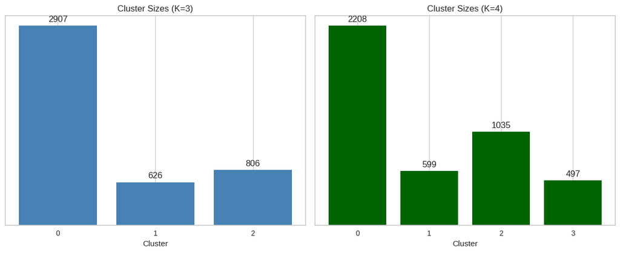

```python
# Create the figure
fig, axes = plt.subplots(1, 2, figsize=(12, 5))

# Cluster sizes
cluster_counts_3 = rfmdata_bw_S_3C['Cluster'].value_counts().sort_index()
cluster_counts_4 = rfmdata_bw_S_4C['Cluster'].value_counts().sort_index()

# Plot K=3
bars_3 = axes[0].bar(
    cluster_counts_3.index.astype(str),
    cluster_counts_3.values,
    color='steelblue'
)
axes[0].set_title('Cluster Sizes (K=3)')
axes[0].set_xlabel('Cluster')
axes[0].set_yticks([])  # Remove y-axis ticks

# Annotate bars
for bar in bars_3:
    height = bar.get_height()
    axes[0].annotate(f'{height}', xy=(bar.get_x() + bar.get_width() / 2, height),
                     xytext=(0, 3), textcoords="offset points", ha='center', va='bottom')

# Plot K=4
bars_4 = axes[1].bar(
    cluster_counts_4.index.astype(str),
    cluster_counts_4.values,
    color='darkgreen'
)
axes[1].set_title('Cluster Sizes (K=4)')
axes[1].set_xlabel('Cluster')
axes[1].set_yticks([])  # Remove y-axis ticks

# Annotate bars
for bar in bars_4:
    height = bar.get_height()
    axes[1].annotate(f'{height}', xy=(bar.get_x() + bar.get_width() / 2, height),
                     xytext=(0, 3), textcoords="offset points", ha='center', va='bottom')

plt.tight_layout()
plt.show()
```

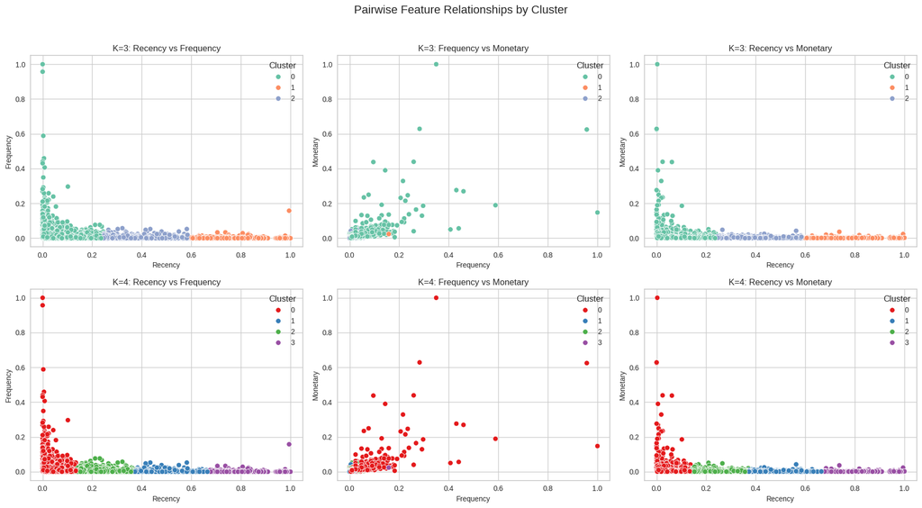

```python
# Create 2x3 subplot layout
fig, axes = plt.subplots(2, 3, figsize=(18, 10))
fig.suptitle("Pairwise Feature Relationships by Cluster", fontsize=16)

# First row: K=3 clustering
sns.scatterplot(data=rfmdata_bw_S_3C, x='Recency', y='Frequency', hue='Cluster', palette='Set2', ax=axes[0, 0])
axes[0, 0].set_title("K=3: Recency vs Frequency")

sns.scatterplot(data=rfmdata_bw_S_3C, x='Frequency', y='Monetary', hue='Cluster', palette='Set2', ax=axes[0, 1])
axes[0, 1].set_title("K=3: Frequency vs Monetary")

sns.scatterplot(data=rfmdata_bw_S_3C, x='Recency', y='Monetary', hue='Cluster', palette='Set2', ax=axes[0, 2])
axes[0, 2].set_title("K=3: Recency vs Monetary")

# Second row: K=4 clustering
sns.scatterplot(data=rfmdata_bw_S_4C, x='Recency', y='Frequency', hue='Cluster', palette='Set1', ax=axes[1, 0])
axes[1, 0].set_title("K=4: Recency vs Frequency")

sns.scatterplot(data=rfmdata_bw_S_4C, x='Frequency', y='Monetary', hue='Cluster', palette='Set1', ax=axes[1, 1])
axes[1, 1].set_title("K=4: Frequency vs Monetary")

sns.scatterplot(data=rfmdata_bw_S_4C, x='Recency', y='Monetary', hue='Cluster', palette='Set1', ax=axes[1, 2])
axes[1, 2].set_title("K=4: Recency vs Monetary")

# Adjust layout and legend
for ax in axes.flatten():
    ax.legend(title='Cluster', loc='upper right')
    ax.set_xlabel(ax.get_xlabel(), fontsize=10)
    ax.set_ylabel(ax.get_ylabel(), fontsize=10)

plt.tight_layout(rect=[0, 0, 1, 0.96])
plt.show()
```

```python
# To Give real meaning values in the Clusters interpretations, we go back to the non-normalized (non Scaled) values
# Assume these are the original non-normalized features
rfm_original = rfmdata[['Recency', 'Frequency', 'Monetary']]  # raw values
rfm_scaled = rfmdata_bw_S[['Recency', 'Frequency', 'Monetary']]  # normalized values

# Fit MinMaxScaler on original data
scaler = MinMaxScaler()
scaler.fit(rfm_original)

# Example: Convert cluster means back to original scale
# Assume cluster_means_scaled is a 2D numpy array or DataFrame
cluster_means_original_3C = scaler.inverse_transform(cluster_means_3C)
cluster_means_original_4C = scaler.inverse_transform(cluster_means_4C)

# Optional: Wrap as DataFrame
cluster_means_original_3C = pd.DataFrame(cluster_means_original_3C, columns=['Recency', 'Frequency', 'Monetary'])
cluster_means_original_4C = pd.DataFrame(cluster_means_original_4C, columns=['Recency', 'Frequency', 'Monetary'])
```

# 5. Final Results and Conclusions

## RFM Clustering Results (K=3)

### Cluster Interpretations:

#### 🟡 Cluster 1 — **Churned Low Spenders**

- **Avg Recency:** 294 days
- **Avg Frequency:** 1.35 purchases
- **Avg Monetary Value:** $607
- **Customer Count:** 626
- **Interpretation:** These are **inactive, one-time or low-frequency buyers** with small transaction amounts.
- **Strategy:** Use **win-back campaigns**, discounts, or reminders to re-engage this group.

#### 🟠 Cluster 2 — **At-Risk Moderate Spenders**

- **Avg Recency:** 153 days
- **Avg Frequency:** 2.22 purchases
- **Avg Monetary Value:** $797
- **Customer Count:** 806
- **Interpretation:** These customers are **moderate in value** and **purchased in the past**, but haven't done so recently. They show signs of **churn risk**.
- **Strategy:** Reconnect with targeted product recommendations and time-limited incentives.

### 📋 Cluster Means Table (K=3)

[output not shown]

## RFM Clustering Results (K=4)

With `K=4`, we get a more granular segmentation of customer behavior. Using the real (denormalized) RFM values, we analyze the characteristics and business value of each segment.

### Cluster Interpretations:

#### 🟣 Cluster 1 — **Churned Moderate Buyers**

- **Avg Recency:** 193 days
- **Avg Frequency:** 1.86 purchases
- **Avg Monetary Value:** $721
- **Customer Count:** 599
- **Interpretation:** Previously active customers with moderate value, but high risk of churn.
- **Strategy:** Launch **re-engagement campaigns** with time-limited discounts.

#### 🔵 Cluster 2 — **Potential Loyalists**

- **Avg Recency:** 84 days
- **Avg Frequency:** 2.60 purchases
- **Avg Monetary Value:** $1,006
- **Customer Count:** 1,035
- **Interpretation:** Mid-frequency and mid-value buyers who have shown interest but need nurturing to become loyal.
- **Strategy:** Offer **personalized upsell** opportunities and track engagement closely.

#### 🟤 Cluster 3 — **Low Value, Inactive Customers**

- **Avg Recency:** 309 days
- **Avg Frequency:** 1.35 purchases
- **Avg Monetary Value:** $567
- **Customer Count:** 497
- **Interpretation:** Least active and low spenders. Likely one-time buyers or abandoned carts.
- **Strategy:** Avoid over-investment. Use **automated drip campaigns** or remove from high-cost targeting.

### 📋 Cluster Means Table (K=4)

[output not shown]